# Populated Pre-Analysis Plan for ‘Feminized victimhood: The political consequences of Global South vulnerability in climate policy discourse’

Leonardo Arriola, Allison Grossman, and Alyssa Heinze

2025-09-01

# Descriptives, treatment assignment, compliance and balance

## Descriptives

|  |  | Mean | SD | N | Percent |
| --- | --- | --- | --- | --- | --- |
| age | 18-24 years old |  |  | 655 | 18.42 |
|  | 25-34 years old |  |  | 934 | 26.27 |
|  | 35-44 years old |  |  | 684 | 19.24 |
|  | 45-54 years old |  |  | 562 | 15.81 |
|  | 55-64 years old |  |  | 421 | 11.84 |
|  | 65-74 years old |  |  | 243 | 6.84 |
|  | 75+ years old |  |  | 56 | 1.58 |
|  | ambivalent_sexism_index | 3.49 | 0.65 | 3555 | 100.00 |
|  | pro_sociality_index | 3.62 | 0.75 | 3555 | 100.00 |
| climate_beliefs | A great deal |  |  | 785 | 22.08 |
|  | A little |  |  | 488 | 13.73 |
|  | A lot |  |  | 1177 | 33.11 |
|  | Don't know |  |  | 83 | 2.33 |
|  | Moderately |  |  | 873 | 24.56 |
|  | Not at all |  |  | 149 | 4.19 |
| trust_government | Don't know |  |  | 479 | 13.47 |
|  | Just about always |  |  | 363 | 10.21 |
|  | Most of the time |  |  | 983 | 27.65 |
|  | Only some of the time |  |  | 1730 | 48.66 |
| male | 0 |  |  | 1630 | 45.85 |
|  | 1 |  |  | 1909 | 53.70 |
| has_children | 0 |  |  | 1483 | 41.72 |
|  | 1 |  |  | 2072 | 58.28 |
| religiosity | 0 |  |  | 927 | 26.08 |
|  | 1 |  |  | 768 | 21.60 |
|  | 2 |  |  | 650 | 18.28 |
|  | 3 |  |  | 355 | 9.99 |
|  | 4 |  |  | 534 | 15.02 |
|  | 5 |  |  | 321 | 9.03 |
| owner_domicile | 0 |  |  | 1838 | 51.70 |
|  | 1 |  |  | 1472 | 41.41 |
| participated_protest_last_12_months | 0 |  |  | 2764 | 77.75 |
|  | 1 |  |  | 791 | 22.25 |
| demanded_action_last_12_months | 0 |  |  | 2803 | 78.85 |
|  | 1 |  |  | 752 | 21.15 |
| employment | A homemaker or stay-at-home parent |  |  | 89 | 2.50 |
|  | Other: |  |  | 51 | 1.43 |
|  | Retired |  |  | 377 | 10.60 |
|  | Student |  |  | 422 | 11.87 |
|  | Unemployed and looking for work |  |  | 301 | 8.47 |
|  | Working full-time |  |  | 1864 | 52.43 |
|  | Working part-time |  |  | 451 | 12.69 |
| education | Informal education only (including Koranic school) |  |  | 35 | 0.98 |
|  | No formal education |  |  | 43 | 1.21 |
|  | Post-university |  |  | 213 | 5.99 |
|  | Primary school |  |  | 68 | 1.91 |
|  | Secondary school |  |  | 1214 | 34.15 |
|  | University |  |  | 1982 | 55.75 |
| nationality | East Asia |  |  | 6 | 0.17 |
|  | Eastern Europe (outside France) |  |  | 35 | 0.98 |
|  | France |  |  | 1739 | 48.92 |
|  | Latin America |  |  | 7 | 0.20 |
|  | North Africa |  |  | 62 | 1.74 |
|  | North America |  |  | 2 | 0.06 |
|  | Oceania |  |  | 3 | 0.08 |
|  | South Asia |  |  | 4 | 0.11 |
|  | Sub-Saharan Africa |  |  | 21 | 0.59 |
|  | Western Europe (outside France) |  |  | 62 | 1.74 |
| ethnicity | Abbey |  |  | 57 | 1.60 |
|  | Abron |  |  | 42 | 1.18 |
|  | Adjoukrou |  |  | 70 | 1.97 |
|  | Agni |  |  | 158 | 4.44 |
|  | Attié |  |  | 90 | 2.53 |
|  | Avikam |  |  | 14 | 0.39 |
|  | Bambara |  |  | 32 | 0.90 |
|  | Baoulé |  |  | 391 | 11.00 |
|  | Bété |  |  | 120 | 3.38 |
|  | Dida |  |  | 38 | 1.07 |
|  | Dioula |  |  | 81 | 2.28 |
|  | Don't know |  |  | 38 | 1.07 |
|  | Godié |  |  | 11 | 0.31 |
|  | Gouro |  |  | 45 | 1.27 |
|  | Guéré |  |  | 54 | 1.52 |
|  | Koulango |  |  | 20 | 0.56 |
|  | Kroumen |  |  | 13 | 0.37 |
|  | Lobi |  |  | 3 | 0.08 |
|  | Malinké/Maninka |  |  | 58 | 1.63 |
|  | Only Ivoirian (do not identify in these terms) |  |  | 100 | 2.81 |
|  | Senoufo |  |  | 117 | 3.29 |
|  | Yacouba |  |  | 62 | 1.74 |

## Treatment assignment and compliance

| treatment | N | Percent |
| --- | --- | --- |
| Man_agent | 881 | 24.78 |
| Man_victim | 889 | 25.01 |
| Woman_agent | 877 | 24.67 |
| Woman_victim | 908 | 25.54 |

| treatment | photo_recall Man holding bucket | photo_recall Man holding sign | photo_recall Woman holding bucket | photo_recall Woman holding sign | gender_photo Don’t know | gender_photo Man | gender_photo There was no person in the photo | gender_photo Woman | victim_agent_photo Don’t know | victim_agent_photo The person was a victim of climate change | victim_agent_photo The person was mobilizing to combat climate change |
| --- | --- | --- | --- | --- | --- | --- | --- | --- | --- | --- | --- |
| Man_agent | 27.00 | 799.00 | 11.00 | 44.00 | 10.00 | 818.00 | 2.00 | 51.00 | 31.00 | 429.00 | 421.00 |
| Man_victim | 678.00 | 34.00 | 154.00 | 23.00 | 5.00 | 711.00 | 3.00 | 170.00 | 29.00 | 770.00 | 90.00 |
| Woman_agent | 5.00 | 77.00 | 23.00 | 772.00 | 1.00 | 71.00 | 2.00 | 803.00 | 16.00 | 300.00 | 561.00 |
| Woman_victim | 20.00 | 17.00 | 825.00 | 46.00 | 4.00 | 28.00 | 3.00 | 873.00 | 39.00 | 779.00 | 90.00 |

## Balance

|  |  | Man_agent (N=881) Mean | Man_agent (N=881) Std. Dev. | Man_victim (N=889) Mean | Man_victim (N=889) Std. Dev. | Woman_agent (N=877) Mean | Woman_agent (N=877) Std. Dev. | Woman_victim (N=908) Mean | Woman_victim (N=908) Std. Dev. |
| --- | --- | --- | --- | --- | --- | --- | --- | --- | --- |
| male |  | 0.5 | 0.5 | 0.5 | 0.5 | 0.5 | 0.5 | 0.5 | 0.5 |
| has_children |  | 0.6 | 0.5 | 0.6 | 0.5 | 0.6 | 0.5 | 0.6 | 0.5 |
| religiosity |  | 1.9 | 1.6 | 1.9 | 1.7 | 2.0 | 1.7 | 1.9 | 1.7 |
| owner_domicile |  | 0.5 | 0.5 | 0.5 | 0.5 | 0.4 | 0.5 | 0.4 | 0.5 |
| ambivalent_sexism_index |  | 3.5 | 0.6 | 3.4 | 0.7 | 3.5 | 0.6 | 3.5 | 0.7 |
| pro_sociality_index |  | 3.6 | 0.8 | 3.6 | 0.8 | 3.6 | 0.7 | 3.6 | 0.7 |
| participated_protest_last_12_months |  | 0.2 | 0.4 | 0.2 | 0.4 | 0.2 | 0.4 | 0.2 | 0.4 |
| demanded_action_last_12_months |  | 0.2 | 0.4 | 0.2 | 0.4 | 0.2 | 0.4 | 0.2 | 0.4 |
|  |  | N | Pct. | N | Pct. | N | Pct. | N | Pct. |
| age | 18-24 years old | 160 | 18.2 | 165 | 18.6 | 176 | 20.1 | 154 | 17.0 |
|  | 25-34 years old | 240 | 27.2 | 222 | 25.0 | 222 | 25.3 | 250 | 27.5 |
|  | 35-44 years old | 168 | 19.1 | 176 | 19.8 | 172 | 19.6 | 168 | 18.5 |
|  | 45-54 years old | 138 | 15.7 | 136 | 15.3 | 129 | 14.7 | 159 | 17.5 |
|  | 55-64 years old | 103 | 11.7 | 107 | 12.0 | 106 | 12.1 | 105 | 11.6 |
|  | 65-74 years old | 66 | 7.5 | 64 | 7.2 | 60 | 6.8 | 53 | 5.8 |
|  | 75+ years old | 6 | 0.7 | 19 | 2.1 | 12 | 1.4 | 19 | 2.1 |
| employment | A homemaker or stay-at-home parent | 18 | 2.0 | 26 | 2.9 | 19 | 2.2 | 26 | 2.9 |
|  | Other: | 11 | 1.2 | 14 | 1.6 | 11 | 1.3 | 15 | 1.7 |
|  | Retired | 91 | 10.3 | 107 | 12.0 | 87 | 9.9 | 92 | 10.1 |
|  | Student | 115 | 13.1 | 93 | 10.5 | 107 | 12.2 | 107 | 11.8 |
|  | Unemployed and looking for work | 70 | 7.9 | 77 | 8.7 | 84 | 9.6 | 70 | 7.7 |
|  | Working full-time | 473 | 53.7 | 466 | 52.4 | 461 | 52.6 | 464 | 51.1 |
|  | Working part-time | 103 | 11.7 | 106 | 11.9 | 108 | 12.3 | 134 | 14.8 |
| education | Informal education only (including Koranic school) | 10 | 1.1 | 8 | 0.9 | 8 | 0.9 | 9 | 1.0 |
|  | No formal education | 13 | 1.5 | 5 | 0.6 | 10 | 1.1 | 15 | 1.7 |
|  | Post-university | 62 | 7.0 | 44 | 4.9 | 58 | 6.6 | 49 | 5.4 |
|  | Primary school | 17 | 1.9 | 19 | 2.1 | 13 | 1.5 | 19 | 2.1 |
|  | Secondary school | 306 | 34.7 | 301 | 33.9 | 285 | 32.5 | 322 | 35.5 |
|  | University | 473 | 53.7 | 512 | 57.6 | 503 | 57.4 | 494 | 54.4 |
| nationality | East Asia | 1 | 0.1 | 1 | 0.1 | 3 | 0.3 | 1 | 0.1 |
|  | Eastern Europe (outside France) | 5 | 0.6 | 13 | 1.5 | 7 | 0.8 | 10 | 1.1 |
|  | France | 435 | 49.4 | 441 | 49.6 | 423 | 48.2 | 440 | 48.5 |
|  | Latin America | 3 | 0.3 | 1 | 0.1 | 1 | 0.1 | 2 | 0.2 |
|  | North Africa | 21 | 2.4 | 12 | 1.3 | 14 | 1.6 | 15 | 1.7 |
|  | North America | 1 | 0.1 | 0 | 0.0 | 0 | 0.0 | 1 | 0.1 |
|  | Oceania | 0 | 0.0 | 0 | 0.0 | 1 | 0.1 | 2 | 0.2 |
|  | South Asia | 2 | 0.2 | 1 | 0.1 | 1 | 0.1 | 0 | 0.0 |
|  | Sub-Saharan Africa | 8 | 0.9 | 6 | 0.7 | 3 | 0.3 | 4 | 0.4 |
|  | Western Europe (outside France) | 12 | 1.4 | 14 | 1.6 | 19 | 2.2 | 17 | 1.9 |
|  | NA | 393 | 44.6 | 400 | 45.0 | 405 | 46.2 | 416 | 45.8 |
| ethnicity | Abbey | 11 | 1.2 | 11 | 1.2 | 14 | 1.6 | 21 | 2.3 |
|  | Abron | 12 | 1.4 | 12 | 1.3 | 6 | 0.7 | 12 | 1.3 |
|  | Adjoukrou | 14 | 1.6 | 22 | 2.5 | 22 | 2.5 | 12 | 1.3 |
|  | Agni | 40 | 4.5 | 36 | 4.0 | 45 | 5.1 | 37 | 4.1 |
|  | Attié | 28 | 3.2 | 27 | 3.0 | 16 | 1.8 | 19 | 2.1 |
|  | Avikam | 4 | 0.5 | 3 | 0.3 | 7 | 0.8 | 0 | 0.0 |
|  | Bambara | 7 | 0.8 | 7 | 0.8 | 11 | 1.3 | 7 | 0.8 |
|  | Baoulé | 96 | 10.9 | 88 | 9.9 | 102 | 11.6 | 105 | 11.6 |
|  | Bété | 23 | 2.6 | 33 | 3.7 | 26 | 3.0 | 38 | 4.2 |
|  | Dida | 7 | 0.8 | 9 | 1.0 | 11 | 1.3 | 11 | 1.2 |
|  | Dioula | 22 | 2.5 | 15 | 1.7 | 22 | 2.5 | 22 | 2.4 |
|  | Don't know | 4 | 0.5 | 11 | 1.2 | 11 | 1.3 | 12 | 1.3 |
|  | Godié | 3 | 0.3 | 1 | 0.1 | 1 | 0.1 | 6 | 0.7 |
|  | Gouro | 6 | 0.7 | 15 | 1.7 | 11 | 1.3 | 13 | 1.4 |
|  | Guéré | 14 | 1.6 | 12 | 1.3 | 12 | 1.4 | 16 | 1.8 |
|  | Koulango | 5 | 0.6 | 11 | 1.2 | 3 | 0.3 | 1 | 0.1 |
|  | Kroumen | 4 | 0.5 | 3 | 0.3 | 3 | 0.3 | 3 | 0.3 |
|  | Lobi | 3 | 0.3 | 0 | 0.0 | 0 | 0.0 | 0 | 0.0 |
|  | Malinké/Maninka | 11 | 1.2 | 16 | 1.8 | 13 | 1.5 | 18 | 2.0 |
|  | Only Ivoirian (do not identify in these terms) | 26 | 3.0 | 24 | 2.7 | 24 | 2.7 | 26 | 2.9 |
|  | Senoufo | 36 | 4.1 | 28 | 3.1 | 33 | 3.8 | 20 | 2.2 |
|  | Yacouba | 17 | 1.9 | 16 | 1.8 | 12 | 1.4 | 17 | 1.9 |
|  | NA | 488 | 55.4 | 489 | 55.0 | 472 | 53.8 | 492 | 54.2 |
| climate_beliefs | A great deal | 185 | 21.0 | 185 | 20.8 | 198 | 22.6 | 217 | 23.9 |
|  | A little | 115 | 13.1 | 128 | 14.4 | 122 | 13.9 | 123 | 13.5 |
|  | A lot | 303 | 34.4 | 308 | 34.6 | 288 | 32.8 | 278 | 30.6 |
|  | Don't know | 25 | 2.8 | 21 | 2.4 | 20 | 2.3 | 17 | 1.9 |
|  | Moderately | 216 | 24.5 | 217 | 24.4 | 213 | 24.3 | 227 | 25.0 |
|  | Not at all | 37 | 4.2 | 30 | 3.4 | 36 | 4.1 | 46 | 5.1 |
| trust_government | Don't know | 114 | 12.9 | 115 | 12.9 | 131 | 14.9 | 119 | 13.1 |
|  | Just about always | 80 | 9.1 | 90 | 10.1 | 95 | 10.8 | 98 | 10.8 |
|  | Most of the time | 248 | 28.1 | 239 | 26.9 | 249 | 28.4 | 247 | 27.2 |
|  | Only some of the time | 439 | 49.8 | 445 | 50.1 | 402 | 45.8 | 444 | 48.9 |

|  | Man victim | Man agent | Woman victim | Woman agent |
| --- | --- | --- | --- | --- |
| (Intercept) | 0.440*** | 0.015 | 0.320** | 0.224* |
|  | (0.106) | (0.104) | (0.113) | (0.108) |
| male | 0.008 | −0.001 | −0.012 | 0.006 |
|  | (0.016) | (0.016) | (0.016) | (0.016) |
| age25-34 years old | −0.054+ | 0.061* | 0.036 | −0.042 |
|  | (0.028) | (0.028) | (0.029) | (0.029) |
| age35-44 years old | −0.039 | 0.043 | 0.023 | −0.027 |
|  | (0.031) | (0.030) | (0.031) | (0.031) |
| age45-54 years old | −0.057+ | 0.042 | 0.057+ | −0.042 |
|  | (0.033) | (0.032) | (0.034) | (0.033) |
| age55-64 years old | −0.058 | 0.041 | 0.019 | −0.002 |
|  | (0.037) | (0.036) | (0.037) | (0.037) |
| age65-74 years old | −0.075 | 0.059 | −0.009 | 0.026 |
|  | (0.055) | (0.056) | (0.056) | (0.052) |
| age75+ years old | 0.003 | −0.115+ | 0.121 | −0.009 |
|  | (0.080) | (0.068) | (0.081) | (0.071) |
| employmentOther × | 0.029 | 0.001 | −0.011 | −0.019 |
|  | (0.083) | (0.074) | (0.084) | (0.076) |
| employmentRetired | 0.027 | 0.040 | −0.037 | −0.030 |
|  | (0.064) | (0.062) | (0.067) | (0.060) |
| employmentStudent | −0.090 | 0.085 | −0.008 | 0.013 |
|  | (0.057) | (0.055) | (0.060) | (0.058) |
| employmentUnemployed and looking for work | −0.009 | 0.031 | −0.077 | 0.056 |
|  | (0.056) | (0.053) | (0.058) | (0.056) |
| employmentWorking full-time | −0.017 | 0.042 | −0.042 | 0.017 |
|  | (0.050) | (0.047) | (0.053) | (0.048) |
| employmentWorking part-time | −0.029 | 0.021 | −0.002 | 0.011 |
|  | (0.053) | (0.050) | (0.056) | (0.052) |
| educationNo formal education | −0.129 | 0.076 | 0.030 | 0.023 |
|  | (0.094) | (0.106) | (0.112) | (0.103) |
| educationPost-university | −0.017 | 0.014 | −0.066 | 0.069 |
|  | (0.083) | (0.085) | (0.090) | (0.083) |
| educationPrimary school | 0.039 | 0.001 | −0.019 | −0.020 |
|  | (0.096) | (0.096) | (0.103) | (0.093) |
| educationSecondary school | 0.010 | −0.010 | −0.023 | 0.023 |
|  | (0.079) | (0.080) | (0.086) | (0.078) |
| educationUniversity | 0.034 | −0.035 | −0.043 | 0.044 |
|  | (0.079) | (0.079) | (0.086) | (0.077) |
| has_children | −0.014 | −0.005 | 0.004 | 0.015 |
|  | (0.018) | (0.018) | (0.019) | (0.018) |
| religiosity | −0.004 | 0.001 | 0.001 | 0.003 |
|  | (0.005) | (0.005) | (0.006) | (0.005) |
| owner_domicile | −0.007 | 0.019 | −0.014 | 0.002 |
|  | (0.017) | (0.017) | (0.018) | (0.018) |
| ambivalent_sexism_index | −0.034** | 0.032* | −0.010 | 0.012 |
|  | (0.012) | (0.012) | (0.013) | (0.012) |
| climate_beliefsA little | 0.007 | 0.008 | −0.018 | 0.004 |
|  | (0.027) | (0.026) | (0.027) | (0.027) |
| climate_beliefsA lot | 0.019 | 0.028 | −0.038+ | −0.009 |
|  | (0.021) | (0.021) | (0.021) | (0.021) |
| climate_beliefsDon't know | −0.020 | 0.080 | −0.053 | −0.007 |
|  | (0.054) | (0.057) | (0.052) | (0.054) |
| climate_beliefsModerately | −0.006 | 0.018 | −0.008 | −0.004 |
|  | (0.023) | (0.023) | (0.023) | (0.023) |
| climate_beliefsNot at all | −0.048 | 0.003 | 0.035 | 0.010 |
|  | (0.039) | (0.040) | (0.044) | (0.042) |
| pro_sociality_index | −0.011 | 0.010 | 0.009 | −0.009 |
|  | (0.012) | (0.012) | (0.012) | (0.012) |
| trust_governmentJust about always | 0.014 | −0.029 | 0.030 | −0.014 |
|  | (0.032) | (0.032) | (0.034) | (0.034) |
| trust_governmentMost of the time | 0.002 | 0.017 | 0.006 | −0.024 |
|  | (0.026) | (0.027) | (0.027) | (0.027) |
| trust_governmentOnly some of the time | 0.022 | 0.011 | 0.011 | −0.044+ |
|  | (0.024) | (0.024) | (0.025) | (0.025) |
| participated_protest_last_12_months | 0.019 | 0.004 | −0.025 | 0.001 |
|  | (0.020) | (0.020) | (0.021) | (0.021) |
| demanded_action_last_12_months | 0.006 | −0.015 | −0.001 | 0.010 |
|  | (0.020) | (0.020) | (0.021) | (0.021) |
| Num.Obs. | 3297 | 3297 | 3297 | 3297 |
| R2 | 0.012 | 0.010 | 0.009 | 0.005 |
| F.statistic | 1.302 | 1.115 | 0.863 | 0.535 |
| F.p.value | 0.116 | 0.298 | 0.692 | 0.986 |

+ p < 0.1, * p < 0.05, ** p < 0.01, *** p < 0.001  
Each model is a linear regression of each treatment group indicator on covariates. All regressions use robust standard errors.

# Main hypothesis 1 (M1).

Feminization of climate change communication will politically demobilize Ivorian citizens. We expect that this will have no effect or a positive effect on French citizens. We present country-wise regressions in the main paper and pooled regressions across the sample in the appendix.

|  | CDI, unadjusted | CDI, adjusted | FR, unadjusted | FR, adjusted | Pooled, unadjusted | Pooled, adjusted |
| --- | --- | --- | --- | --- | --- | --- |
| (Intercept) | −0.461*** | 3.290*** | 0.352*** | 2.286*** | −0.014 | 3.492*** |
|  | (0.048) | (0.778) | (0.046) | (0.554) | (0.035) | (0.312) |
| treatment_female | 0.058 | 0.064 | 0.019 | 0.016 | 0.028 | 0.034 |
|  | (0.067) | (0.067) | (0.065) | (0.057) | (0.049) | (0.045) |
| male |  | −0.168* |  | 0.040 |  | −0.027 |
|  |  | (0.077) |  | (0.061) |  | (0.046) |
| age25-34 years old |  | −0.339** |  | −0.036 |  | −0.264** |
|  |  | (0.107) |  | (0.146) |  | (0.086) |
| age35-44 years old |  | −0.380** |  | −0.096 |  | −0.175+ |
|  |  | (0.127) |  | (0.147) |  | (0.093) |
| age45-54 years old |  | −0.505** |  | −0.082 |  | −0.099 |
|  |  | (0.160) |  | (0.149) |  | (0.099) |
| age55-64 years old |  | −0.285 |  | −0.355* |  | −0.217* |
|  |  | (0.346) |  | (0.153) |  | (0.110) |
| age75+ years old |  | 0.698+ |  | −0.203 |  | 0.045 |
|  |  | (0.370) |  | (0.233) |  | (0.211) |
| employmentOther × |  | −0.074 |  | 0.213 |  | −0.137 |
|  |  | (0.334) |  | (0.241) |  | (0.197) |
| employmentRetired |  | 0.499 |  | 0.229 |  | 0.030 |
|  |  | (0.663) |  | (0.202) |  | (0.181) |
| employmentStudent |  | 0.228 |  | −0.007 |  | 0.156 |
|  |  | (0.271) |  | (0.247) |  | (0.165) |
| employmentUnemployed and looking for work |  | 0.065 |  | 0.292 |  | 0.104 |
|  |  | (0.268) |  | (0.232) |  | (0.163) |
| employmentWorking full-time |  | 0.043 |  | 0.318+ |  | 0.143 |
|  |  | (0.256) |  | (0.170) |  | (0.140) |
| employmentWorking part-time |  | −0.034 |  | 0.423* |  | 0.056 |
|  |  | (0.260) |  | (0.189) |  | (0.147) |
| educationNo formal education |  | −0.953 |  | −0.480 |  | −0.619* |
|  |  | (0.826) |  | (0.359) |  | (0.315) |

[output cut: 103 more lines]

+ p < 0.1, * p < 0.05, ** p < 0.01, *** p < 0.001  
Note: Outcome is a PCA index of the three political mobilization outcomes. Robust SEs.

# Main hypothesis 2 (M2).

Victimization of climate change communication will politically demobilize Global South citizens. We expect that this will have no effect or a positive effect on French citizens. We present country-wise regressions in the main paper and pooled regressions across the sample in the appendix.

|  | CDI, unadjusted | CDI, adjusted | FR, unadjusted | FR, adjusted | Pooled, unadjusted | Pooled, adjusted |
| --- | --- | --- | --- | --- | --- | --- |
| (Intercept) | −0.455*** | 3.271*** | 0.339*** | 2.273*** | −0.023 | 3.495*** |
|  | (0.048) | (0.756) | (0.045) | (0.550) | (0.034) | (0.312) |
| treatment_victim | 0.047 | 0.065 | 0.044 | 0.037 | 0.046 | 0.020 |
|  | (0.067) | (0.067) | (0.065) | (0.057) | (0.049) | (0.044) |
| male |  | −0.167* |  | 0.040 |  | −0.027 |
|  |  | (0.077) |  | (0.061) |  | (0.046) |
| age25-34 years old |  | −0.338** |  | −0.035 |  | −0.264** |
|  |  | (0.107) |  | (0.146) |  | (0.086) |
| age35-44 years old |  | −0.382** |  | −0.094 |  | −0.175+ |
|  |  | (0.128) |  | (0.148) |  | (0.093) |
| age45-54 years old |  | −0.510** |  | −0.081 |  | −0.099 |
|  |  | (0.160) |  | (0.149) |  | (0.099) |
| age55-64 years old |  | −0.293 |  | −0.352* |  | −0.216+ |
|  |  | (0.347) |  | (0.153) |  | (0.110) |
| age75+ years old |  | 0.688+ |  | −0.205 |  | 0.047 |
|  |  | (0.375) |  | (0.233) |  | (0.211) |
| employmentOther × |  | −0.064 |  | 0.213 |  | −0.139 |
|  |  | (0.333) |  | (0.239) |  | (0.197) |
| employmentRetired |  | 0.500 |  | 0.228 |  | 0.028 |
|  |  | (0.661) |  | (0.201) |  | (0.181) |
| employmentStudent |  | 0.243 |  | −0.004 |  | 0.158 |
|  |  | (0.272) |  | (0.248) |  | (0.166) |
| employmentUnemployed and looking for work |  | 0.078 |  | 0.293 |  | 0.105 |
|  |  | (0.269) |  | (0.232) |  | (0.163) |
| employmentWorking full-time |  | 0.056 |  | 0.318+ |  | 0.143 |
|  |  | (0.257) |  | (0.170) |  | (0.140) |
| employmentWorking part-time |  | −0.024 |  | 0.425* |  | 0.057 |
|  |  | (0.261) |  | (0.189) |  | (0.148) |
| educationNo formal education |  | −0.942 |  | −0.474 |  | −0.615+ |
|  |  | (0.809) |  | (0.360) |  | (0.315) |

[output cut: 103 more lines]

+ p < 0.1, * p < 0.05, ** p < 0.01, *** p < 0.001  
Note: Outcome is a PCA index of the three political mobilization outcomes. Robust SEs.

# Main hypothesis 3 (M3).

Feminization of climate change communication will increase support for Global South climate financing among Global North citizens (for all outcomes). We expect the same among Global South citizens but only for 5/6 outcomes. For Global South citizens, we expect the last outcome (willingness to pay) to move in the opposite direction. We present country-wise regressions in the main paper and pooled regressions across the sample in the appendix.

|  | Prefers adaptation finance in poor countries vs. France Unadjusted | Prefers adaptation finance in poor countries vs. France Adjusted | Prefers adaptation finance vs. emergency relief Unadjusted | Prefers adaptation finance vs. emergency relief Adjusted | Prefers gender-based adaptation finance vs. general programming Unadjusted | Prefers gender-based adaptation finance vs. general programming Adjusted | Willingness to sign petition Unadjusted | Willingness to sign petition Adjusted | Clicks to learn more about climate adaptation Unadjusted | Clicks to learn more about climate adaptation Adjusted | Willingness to pay Unadjusted | Willingness to pay Adjusted |
| --- | --- | --- | --- | --- | --- | --- | --- | --- | --- | --- | --- | --- |
| (Intercept) | 0.846*** | 0.498+ | 0.444*** | 0.440+ | 0.329*** | −0.070 | 0.842*** | 0.509* | 0.107*** | 0.063 | 0.792*** | 0.500*** |
|  | (0.013) | (0.296) | (0.018) | (0.231) | (0.017) | (0.334) | (0.013) | (0.244) | (0.011) | (0.091) | (0.014) | (0.123) |
| treatment_female | −0.012 | −0.005 | −0.003 | −0.003 | 0.134*** | 0.151*** | −0.029 | −0.037+ | 0.009 | 0.003 | 0.019 | 0.024 |
|  | (0.018) | (0.019) | (0.025) | (0.027) | (0.024) | (0.025) | (0.019) | (0.019) | (0.016) | (0.017) | (0.020) | (0.020) |
| male |  | 0.033 |  | 0.031 |  | −0.054+ |  | 0.068** |  | 0.036+ |  | 0.007 |
|  |  | (0.022) |  | (0.030) |  | (0.028) |  | (0.023) |  | (0.019) |  | (0.023) |
| age25-34 years old |  | 0.014 |  | 0.033 |  | 0.020 |  | 0.024 |  | 0.002 |  | 0.062* |
|  |  | (0.029) |  | (0.042) |  | (0.039) |  | (0.032) |  | (0.027) |  | (0.031) |
| age35-44 years old |  | 0.021 |  | 0.046 |  | 0.074 |  | 0.039 |  | 0.055+ |  | 0.032 |
|  |  | (0.035) |  | (0.049) |  | (0.046) |  | (0.035) |  | (0.032) |  | (0.037) |
| age45-54 years old |  | −0.015 |  | 0.051 |  | 0.097+ |  | 0.069+ |  | 0.102* |  | 0.010 |
|  |  | (0.045) |  | (0.062) |  | (0.058) |  | (0.042) |  | (0.046) |  | (0.046) |
| age55-64 years old |  | −0.089 |  | 0.194+ |  | −0.037 |  | −0.054 |  | 0.100 |  | −0.044 |
|  |  | (0.103) |  | (0.104) |  | (0.098) |  | (0.094) |  | (0.087) |  | (0.090) |
| age75+ years old |  | 0.533*** |  | −0.671*** |  | 0.362* |  | 0.254* |  | 0.051 |  | −1.009*** |
|  |  | (0.126) |  | (0.156) |  | (0.160) |  | (0.116) |  | (0.059) |  | (0.067) |
| employmentOther × |  | 0.084 |  | 0.197 |  | 0.010 |  | −0.011 |  | −0.053 |  | 0.176 |
|  |  | (0.099) |  | (0.141) |  | (0.127) |  | (0.088) |  | (0.102) |  | (0.128) |
| employmentRetired |  | −0.195 |  | 0.064 |  | 0.016 |  | −0.106 |  | −0.021 |  | 0.400** |
|  |  | (0.229) |  | (0.209) |  | (0.198) |  | (0.155) |  | (0.166) |  | (0.123) |
| employmentStudent |  | 0.122 |  | 0.033 |  | −0.019 |  | −0.178* |  | −0.089 |  | 0.229* |
|  |  | (0.086) |  | (0.109) |  | (0.099) |  | (0.077) |  | (0.073) |  | (0.099) |
| employmentUnemployed and looking for work |  | 0.104 |  | −0.027 |  | −0.039 |  | −0.057 |  | −0.056 |  | 0.257** |
|  |  | (0.085) |  | (0.108) |  | (0.099) |  | (0.075) |  | (0.072) |  | (0.098) |
| employmentWorking full-time |  | 0.055 |  | 0.070 |  | −0.032 |  | −0.101 |  | −0.084 |  | 0.252** |
|  |  | (0.082) |  | (0.104) |  | (0.095) |  | (0.072) |  | (0.068) |  | (0.095) |
| employmentWorking part-time |  | 0.035 |  | 0.054 |  | 0.011 |  | −0.074 |  | −0.057 |  | 0.245* |
|  |  | (0.084) |  | (0.106) |  | (0.097) |  | (0.073) |  | (0.070) |  | (0.097) |
| educationNo formal education |  | −0.025 |  | 0.317 |  | 0.089 |  | 0.102 |  | 0.024 |  | −0.098 |
|  |  | (0.306) |  | (0.249) |  | (0.332) |  | (0.227) |  | (0.053) |  | (0.080) |

[output cut: 83 more lines]

+ p < 0.1, * p < 0.05, ** p < 0.01, *** p < 0.001  
Note: 6 climate adpatation outcomes. Run on Ivorian sample. Robust SEs.

|  | Prefers adaptation finance in poor countries vs. France Unadjusted | Prefers adaptation finance in poor countries vs. France Adjusted | Prefers adaptation finance vs. emergency relief Unadjusted | Prefers adaptation finance vs. emergency relief Adjusted | Prefers gender-based adaptation finance vs. general programming Unadjusted | Prefers gender-based adaptation finance vs. general programming Adjusted | Willingness to sign petition Unadjusted | Willingness to sign petition Adjusted | Clicks to learn more about climate adaptation Unadjusted | Clicks to learn more about climate adaptation Adjusted | Willingness to pay Unadjusted | Willingness to pay Adjusted |
| --- | --- | --- | --- | --- | --- | --- | --- | --- | --- | --- | --- | --- |
| (Intercept) | 0.436*** | 0.383 | 0.498*** | 0.489+ | 0.268*** | −0.030 | 0.510*** | 0.314 | 0.039*** | −0.132** | 0.488*** | 0.245 |
|  | (0.016) | (0.299) | (0.016) | (0.278) | (0.014) | (0.307) | (0.016) | (0.293) | (0.006) | (0.047) | (0.016) | (0.273) |
| treatment_female | −0.032 | −0.040+ | 0.005 | 0.008 | 0.092*** | 0.095*** | −0.021 | −0.021 | −0.005 | −0.006 | 0.016 | 0.018 |
|  | (0.023) | (0.022) | (0.023) | (0.023) | (0.021) | (0.021) | (0.023) | (0.022) | (0.009) | (0.009) | (0.023) | (0.022) |
| male |  | −0.041+ |  | 0.037 |  | −0.030 |  | −0.028 |  | 0.001 |  | −0.011 |
|  |  | (0.024) |  | (0.024) |  | (0.022) |  | (0.023) |  | (0.010) |  | (0.023) |
| age25-34 years old |  | −0.102+ |  | 0.162** |  | 0.021 |  | 0.051 |  | 0.005 |  | −0.109+ |
|  |  | (0.057) |  | (0.054) |  | (0.056) |  | (0.056) |  | (0.014) |  | (0.056) |
| age35-44 years old |  | −0.091 |  | 0.189*** |  | 0.045 |  | 0.064 |  | 0.008 |  | −0.050 |
|  |  | (0.058) |  | (0.055) |  | (0.056) |  | (0.057) |  | (0.014) |  | (0.057) |
| age45-54 years old |  | −0.145* |  | 0.200*** |  | 0.021 |  | 0.061 |  | 0.031+ |  | −0.105+ |
|  |  | (0.057) |  | (0.055) |  | (0.056) |  | (0.056) |  | (0.017) |  | (0.056) |
| age55-64 years old |  | −0.088 |  | 0.268*** |  | −0.001 |  | 0.065 |  | 0.043* |  | −0.014 |
|  |  | (0.060) |  | (0.056) |  | (0.057) |  | (0.059) |  | (0.018) |  | (0.058) |
| age65-74 years old |  | −0.049 |  | 0.229** |  | −0.000 |  | 0.050 |  | 0.010 |  | 0.048 |
|  |  | (0.076) |  | (0.074) |  | (0.071) |  | (0.073) |  | (0.029) |  | (0.075) |
| age75+ years old |  | 0.056 |  | 0.366*** |  | −0.071 |  | 0.038 |  | −0.008 |  | 0.129 |
|  |  | (0.101) |  | (0.097) |  | (0.085) |  | (0.097) |  | (0.033) |  | (0.097) |
| employmentOther × |  | −0.230* |  | −0.032 |  | 0.174 |  | −0.027 |  | 0.019 |  | −0.012 |
|  |  | (0.115) |  | (0.129) |  | (0.124) |  | (0.117) |  | (0.048) |  | (0.110) |
| employmentRetired |  | −0.133 |  | −0.093 |  | 0.032 |  | −0.144+ |  | 0.031 |  | −0.043 |
|  |  | (0.084) |  | (0.083) |  | (0.074) |  | (0.077) |  | (0.031) |  | (0.076) |
| employmentStudent |  | −0.105 |  | −0.020 |  | 0.037 |  | −0.120 |  | 0.014 |  | −0.020 |
|  |  | (0.106) |  | (0.107) |  | (0.102) |  | (0.103) |  | (0.029) |  | (0.099) |
| employmentUnemployed and looking for work |  | −0.098 |  | −0.113 |  | −0.002 |  | −0.175* |  | 0.055 |  | −0.036 |
|  |  | (0.091) |  | (0.090) |  | (0.082) |  | (0.087) |  | (0.035) |  | (0.085) |
| employmentWorking full-time |  | −0.098 |  | −0.059 |  | 0.013 |  | −0.170** |  | 0.007 |  | 0.005 |
|  |  | (0.071) |  | (0.069) |  | (0.063) |  | (0.065) |  | (0.020) |  | (0.062) |
| employmentWorking part-time |  | −0.080 |  | −0.054 |  | 0.065 |  | −0.108 |  | 0.006 |  | −0.006 |
|  |  | (0.080) |  | (0.078) |  | (0.072) |  | (0.074) |  | (0.023) |  | (0.071) |

[output cut: 61 more lines]

+ p < 0.1, * p < 0.05, ** p < 0.01, *** p < 0.001  
Note: 6 climate adpatation outcomes. Run on French sample. Robust SEs.

|  | Prefers adaptation finance in poor countries vs. France Unadjusted | Prefers adaptation finance in poor countries vs. France Adjusted | Prefers adaptation finance vs. emergency relief Unadjusted | Prefers adaptation finance vs. emergency relief Adjusted | Prefers gender-based adaptation finance vs. general programming Unadjusted | Prefers gender-based adaptation finance vs. general programming Adjusted | Willingness to sign petition Unadjusted | Willingness to sign petition Adjusted | Clicks to learn more about climate adaptation Unadjusted | Clicks to learn more about climate adaptation Adjusted | Willingness to pay Unadjusted | Willingness to pay Adjusted |
| --- | --- | --- | --- | --- | --- | --- | --- | --- | --- | --- | --- | --- |
| (Intercept) | 0.621*** | 0.287* | 0.474*** | 0.601*** | 0.296*** | −0.047 | 0.660*** | 0.246* | 0.070*** | −0.051 | 0.625*** | 0.166 |
|  | (0.012) | (0.122) | (0.012) | (0.125) | (0.011) | (0.123) | (0.011) | (0.112) | (0.006) | (0.044) | (0.012) | (0.106) |
| treatment_female | −0.018 | −0.029+ | 0.001 | 0.008 | 0.112*** | 0.114*** | −0.021 | −0.030* | 0.002 | −0.002 | 0.021 | 0.022 |
|  | (0.016) | (0.016) | (0.017) | (0.017) | (0.016) | (0.016) | (0.016) | (0.015) | (0.009) | (0.009) | (0.016) | (0.016) |
| male |  | 0.005 |  | 0.047** |  | −0.047** |  | 0.023 |  | 0.026** |  | 0.015 |
|  |  | (0.016) |  | (0.018) |  | (0.017) |  | (0.016) |  | (0.009) |  | (0.016) |
| age25-34 years old |  | −0.018 |  | 0.085** |  | 0.032 |  | 0.025 |  | −0.001 |  | −0.005 |
|  |  | (0.028) |  | (0.032) |  | (0.031) |  | (0.029) |  | (0.018) |  | (0.028) |
| age35-44 years old |  | −0.061* |  | 0.123*** |  | 0.056 |  | −0.006 |  | 0.020 |  | −0.042 |
|  |  | (0.031) |  | (0.035) |  | (0.034) |  | (0.031) |  | (0.019) |  | (0.031) |
| age45-54 years old |  | −0.152*** |  | 0.135*** |  | 0.033 |  | −0.041 |  | 0.039+ |  | −0.124*** |
|  |  | (0.034) |  | (0.038) |  | (0.036) |  | (0.033) |  | (0.020) |  | (0.034) |
| age55-64 years old |  | −0.149*** |  | 0.202*** |  | −0.015 |  | −0.083* |  | 0.038+ |  | −0.080* |
|  |  | (0.039) |  | (0.041) |  | (0.039) |  | (0.038) |  | (0.022) |  | (0.038) |
| age65-74 years old |  | −0.103+ |  | 0.160* |  | −0.013 |  | −0.093+ |  | −0.001 |  | −0.043 |
|  |  | (0.061) |  | (0.063) |  | (0.056) |  | (0.056) |  | (0.031) |  | (0.060) |
| age75+ years old |  | −0.011 |  | 0.278** |  | −0.088 |  | −0.115 |  | −0.018 |  | 0.011 |
|  |  | (0.088) |  | (0.088) |  | (0.072) |  | (0.084) |  | (0.034) |  | (0.088) |
| employmentOther × |  | −0.021 |  | 0.058 |  | 0.124 |  | 0.035 |  | 0.018 |  | 0.107 |
|  |  | (0.082) |  | (0.092) |  | (0.086) |  | (0.070) |  | (0.052) |  | (0.081) |
| employmentRetired |  | −0.080 |  | −0.049 |  | 0.029 |  | −0.113+ |  | 0.013 |  | 0.076 |
|  |  | (0.072) |  | (0.073) |  | (0.065) |  | (0.063) |  | (0.036) |  | (0.068) |
| employmentStudent |  | 0.067 |  | −0.033 |  | 0.013 |  | −0.133* |  | −0.001 |  | 0.098 |
|  |  | (0.062) |  | (0.065) |  | (0.061) |  | (0.057) |  | (0.034) |  | (0.060) |
| employmentUnemployed and looking for work |  | 0.041 |  | −0.095 |  | −0.004 |  | −0.071 |  | 0.029 |  | 0.125* |
|  |  | (0.060) |  | (0.063) |  | (0.060) |  | (0.055) |  | (0.034) |  | (0.058) |
| employmentWorking full-time |  | −0.045 |  | −0.031 |  | 0.008 |  | −0.137** |  | −0.020 |  | 0.092+ |
|  |  | (0.055) |  | (0.056) |  | (0.052) |  | (0.049) |  | (0.027) |  | (0.052) |
| employmentWorking part-time |  | 0.009 |  | −0.019 |  | 0.052 |  | −0.054 |  | 0.015 |  | 0.119* |
|  |  | (0.058) |  | (0.060) |  | (0.056) |  | (0.051) |  | (0.030) |  | (0.055) |
| educationNo formal education |  | −0.039 |  | −0.075 |  | 0.059 |  | −0.033 |  | −0.011 |  | −0.053 |
|  |  | (0.122) |  | (0.120) |  | (0.120) |  | (0.104) |  | (0.013) |  | (0.101) |
| educationPost-university |  | 0.045 |  | 0.052 |  | −0.072 |  | −0.069 |  | 0.067** |  | −0.133 |
|  |  | (0.100) |  | (0.097) |  | (0.099) |  | (0.088) |  | (0.023) |  | (0.081) |
| educationPrimary school |  | 0.127 |  | −0.069 |  | 0.136 |  | 0.012 |  | 0.029 |  | −0.146 |
|  |  | (0.110) |  | (0.111) |  | (0.112) |  | (0.101) |  | (0.027) |  | (0.094) |
| educationSecondary school |  | 0.058 |  | −0.067 |  | −0.069 |  | −0.095 |  | 0.042** |  | −0.156* |
|  |  | (0.095) |  | (0.092) |  | (0.095) |  | (0.084) |  | (0.014) |  | (0.075) |
| educationUniversity |  | 0.085 |  | −0.015 |  | −0.075 |  | −0.087 |  | 0.055*** |  | −0.123+ |
|  |  | (0.095) |  | (0.092) |  | (0.094) |  | (0.083) |  | (0.012) |  | (0.074) |
| has_children |  | 0.027 |  | −0.029 |  | 0.058** |  | 0.051** |  | 0.005 |  | 0.041* |
|  |  | (0.019) |  | (0.021) |  | (0.019) |  | (0.019) |  | (0.010) |  | (0.019) |
| religiosity |  | 0.032*** |  | 0.002 |  | −0.002 |  | 0.028*** |  | 0.012*** |  | 0.036*** |
|  |  | (0.005) |  | (0.006) |  | (0.006) |  | (0.005) |  | (0.003) |  | (0.006) |
| owner_domicile |  | −0.113*** |  | 0.017 |  | −0.028 |  | −0.084*** |  | −0.025* |  | −0.043* |
|  |  | (0.019) |  | (0.020) |  | (0.019) |  | (0.018) |  | (0.010) |  | (0.018) |
| ambivalent_sexism_index |  | 0.027* |  | −0.047** |  | 0.083*** |  | 0.039** |  | 0.007 |  | 0.014 |
|  |  | (0.013) |  | (0.014) |  | (0.014) |  | (0.013) |  | (0.008) |  | (0.013) |
| climate_beliefsA little |  | −0.017 |  | −0.043 |  | 0.041 |  | −0.062* |  | −0.038* |  | −0.064* |
|  |  | (0.027) |  | (0.031) |  | (0.029) |  | (0.026) |  | (0.016) |  | (0.027) |
| climate_beliefsA lot |  | −0.033 |  | −0.006 |  | −0.008 |  | −0.027 |  | −0.027+ |  | −0.013 |
|  |  | (0.021) |  | (0.024) |  | (0.023) |  | (0.021) |  | (0.014) |  | (0.021) |
| climate_beliefsDon't know |  | −0.078 |  | −0.010 |  | 0.161** |  | −0.127* |  | −0.041 |  | −0.108+ |
|  |  | (0.059) |  | (0.062) |  | (0.060) |  | (0.060) |  | (0.027) |  | (0.059) |
| climate_beliefsModerately |  | −0.098*** |  | −0.040 |  | −0.012 |  | −0.067** |  | −0.049*** |  | −0.048* |
|  |  | (0.024) |  | (0.026) |  | (0.025) |  | (0.023) |  | (0.013) |  | (0.023) |
| climate_beliefsNot at all |  | −0.046 |  | −0.004 |  | 0.046 |  | −0.065 |  | −0.053** |  | −0.067+ |
|  |  | (0.043) |  | (0.048) |  | (0.045) |  | (0.042) |  | (0.019) |  | (0.041) |
| pro_sociality_index |  | 0.087*** |  | −0.012 |  | 0.005 |  | 0.101*** |  | 0.007 |  | 0.096*** |
|  |  | (0.012) |  | (0.014) |  | (0.013) |  | (0.012) |  | (0.006) |  | (0.012) |
| trust_governmentJust about always |  | −0.046 |  | 0.044 |  | 0.072* |  | 0.114*** |  | 0.015 |  | 0.171*** |
|  |  | (0.033) |  | (0.037) |  | (0.036) |  | (0.032) |  | (0.020) |  | (0.031) |
| trust_governmentMost of the time |  | −0.041 |  | 0.039 |  | 0.081** |  | 0.111*** |  | 0.026+ |  | 0.128*** |
|  |  | (0.026) |  | (0.031) |  | (0.029) |  | (0.027) |  | (0.016) |  | (0.027) |
| trust_governmentOnly some of the time |  | −0.095*** |  | 0.029 |  | −0.011 |  | 0.041 |  | 0.008 |  | 0.031 |
|  |  | (0.024) |  | (0.028) |  | (0.026) |  | (0.026) |  | (0.014) |  | (0.026) |
| participated_protest_last_12_months |  | 0.049* |  | 0.055* |  | 0.095*** |  | 0.135*** |  | 0.003 |  | 0.089*** |
|  |  | (0.021) |  | (0.024) |  | (0.023) |  | (0.019) |  | (0.013) |  | (0.021) |
| demanded_action_last_12_months |  | 0.028 |  | −0.028 |  | 0.076*** |  | 0.082*** |  | 0.011 |  | 0.060** |
|  |  | (0.021) |  | (0.024) |  | (0.023) |  | (0.019) |  | (0.013) |  | (0.021) |
| R2 | 0.00 | 0.18 | 0.00 | 0.03 | 0.01 | 0.08 | 0.00 | 0.18 | 0.00 | 0.04 | 0.00 | 0.16 |
| Num. obs. | 3526 | 3268 | 3527 | 3269 | 3529 | 3271 | 3529 | 3271 | 3522 | 3264 | 3529 | 3271 |
| RMSE | 0.49 | 0.44 | 0.50 | 0.49 | 0.47 | 0.46 | 0.48 | 0.43 | 0.26 | 0.25 | 0.48 | 0.44 |

+ p < 0.1, * p < 0.05, ** p < 0.01, *** p < 0.001  
Note: 6 climate adpatation outcomes. Run on pooled sample. Robust SEs.

# Main hypothesis 4 (M4).

|  | Prefers adaptation finance in poor countries vs. France Unadjusted | Prefers adaptation finance in poor countries vs. France Adjusted | Prefers adaptation finance vs. emergency relief Unadjusted | Prefers adaptation finance vs. emergency relief Adjusted | Prefers gender-based adaptation finance vs. general programming Unadjusted | Prefers gender-based adaptation finance vs. general programming Adjusted | Willingness to sign petition Unadjusted | Willingness to sign petition Adjusted | Clicks to learn more about climate adaptation Unadjusted | Clicks to learn more about climate adaptation Adjusted | Willingness to pay Unadjusted | Willingness to pay Adjusted |
| --- | --- | --- | --- | --- | --- | --- | --- | --- | --- | --- | --- | --- |
| (Intercept) | 0.841*** | 0.488+ | 0.455*** | 0.461* | 0.409*** | 0.053 | 0.823*** | 0.469+ | 0.108*** | 0.053 | 0.827*** | 0.550*** |
|  | (0.013) | (0.295) | (0.018) | (0.234) | (0.017) | (0.344) | (0.014) | (0.247) | (0.011) | (0.091) | (0.013) | (0.119) |
| treatment_victim | −0.001 | 0.008 | −0.025 | −0.027 | −0.022 | −0.038 | 0.009 | 0.021 | 0.007 | 0.013 | −0.050* | −0.040* |
|  | (0.018) | (0.019) | (0.025) | (0.027) | (0.024) | (0.026) | (0.019) | (0.020) | (0.016) | (0.017) | (0.020) | (0.020) |
| male |  | 0.034 |  | 0.030 |  | −0.054+ |  | 0.069** |  | 0.036+ |  | 0.006 |
|  |  | (0.022) |  | (0.030) |  | (0.028) |  | (0.023) |  | (0.019) |  | (0.023) |
| age25-34 years old |  | 0.015 |  | 0.033 |  | 0.020 |  | 0.024 |  | 0.002 |  | 0.062* |
|  |  | (0.029) |  | (0.042) |  | (0.039) |  | (0.032) |  | (0.027) |  | (0.031) |
| age35-44 years old |  | 0.021 |  | 0.047 |  | 0.071 |  | 0.040 |  | 0.054+ |  | 0.032 |
|  |  | (0.035) |  | (0.049) |  | (0.047) |  | (0.035) |  | (0.032) |  | (0.037) |
| age45-54 years old |  | −0.015 |  | 0.053 |  | 0.100+ |  | 0.068 |  | 0.101* |  | 0.013 |
|  |  | (0.045) |  | (0.062) |  | (0.059) |  | (0.042) |  | (0.046) |  | (0.046) |
| age55-64 years old |  | −0.089 |  | 0.194+ |  | −0.054 |  | −0.049 |  | 0.100 |  | −0.047 |
|  |  | (0.103) |  | (0.104) |  | (0.098) |  | (0.094) |  | (0.087) |  | (0.091) |
| age75+ years old |  | 0.527*** |  | −0.656*** |  | 0.451** |  | 0.226+ |  | 0.044 |  | −0.975*** |
|  |  | (0.125) |  | (0.156) |  | (0.160) |  | (0.117) |  | (0.058) |  | (0.069) |
| employmentOther × |  | 0.083 |  | 0.198 |  | 0.044 |  | −0.020 |  | −0.053 |  | 0.184 |
|  |  | (0.099) |  | (0.140) |  | (0.130) |  | (0.088) |  | (0.101) |  | (0.128) |
| employmentRetired |  | −0.197 |  | 0.070 |  | 0.059 |  | −0.119 |  | −0.023 |  | 0.414*** |
|  |  | (0.229) |  | (0.208) |  | (0.201) |  | (0.156) |  | (0.167) |  | (0.123) |
| employmentStudent |  | 0.123 |  | 0.028 |  | −0.012 |  | −0.178* |  | −0.086 |  | 0.225* |
|  |  | (0.086) |  | (0.109) |  | (0.101) |  | (0.077) |  | (0.073) |  | (0.098) |
| employmentUnemployed and looking for work |  | 0.105 |  | −0.030 |  | −0.028 |  | −0.058 |  | −0.054 |  | 0.255** |
|  |  | (0.085) |  | (0.107) |  | (0.101) |  | (0.075) |  | (0.072) |  | (0.097) |
| employmentWorking full-time |  | 0.056 |  | 0.066 |  | −0.026 |  | −0.101 |  | −0.082 |  | 0.249** |
|  |  | (0.082) |  | (0.103) |  | (0.096) |  | (0.071) |  | (0.068) |  | (0.095) |
| employmentWorking part-time |  | 0.035 |  | 0.052 |  | 0.025 |  | −0.077 |  | −0.056 |  | 0.245* |
|  |  | (0.084) |  | (0.105) |  | (0.098) |  | (0.072) |  | (0.070) |  | (0.096) |
| educationNo formal education |  | −0.024 |  | 0.313 |  | 0.087 |  | 0.104 |  | 0.026 |  | −0.103 |
|  |  | (0.305) |  | (0.252) |  | (0.335) |  | (0.228) |  | (0.051) |  | (0.074) |

[output cut: 83 more lines]

+ p < 0.1, * p < 0.05, ** p < 0.01, *** p < 0.001  
Note: 6 climate adpatation outcomes. Run on Ivorian sample. Robust SEs.

|  | Prefers adaptation finance in poor countries vs. France Unadjusted | Prefers adaptation finance in poor countries vs. France Adjusted | Prefers adaptation finance vs. emergency relief Unadjusted | Prefers adaptation finance vs. emergency relief Adjusted | Prefers gender-based adaptation finance vs. general programming Unadjusted | Prefers gender-based adaptation finance vs. general programming Adjusted | Willingness to sign petition Unadjusted | Willingness to sign petition Adjusted | Clicks to learn more about climate adaptation Unadjusted | Clicks to learn more about climate adaptation Adjusted | Willingness to pay Unadjusted | Willingness to pay Adjusted |
| --- | --- | --- | --- | --- | --- | --- | --- | --- | --- | --- | --- | --- |
| (Intercept) | 0.433*** | 0.373 | 0.518*** | 0.518+ | 0.308*** | 0.021 | 0.504*** | 0.307 | 0.038*** | −0.136** | 0.501*** | 0.267 |
|  | (0.016) | (0.302) | (0.016) | (0.277) | (0.015) | (0.302) | (0.016) | (0.296) | (0.006) | (0.046) | (0.016) | (0.272) |
| treatment_victim | −0.026 | −0.028 | −0.035 | −0.033 | 0.013 | 0.027 | −0.009 | −0.013 | −0.004 | −0.000 | −0.011 | −0.012 |
|  | (0.023) | (0.023) | (0.023) | (0.023) | (0.021) | (0.021) | (0.023) | (0.022) | (0.009) | (0.009) | (0.023) | (0.022) |
| male |  | −0.041+ |  | 0.036 |  | −0.031 |  | −0.028 |  | 0.001 |  | −0.011 |
|  |  | (0.024) |  | (0.024) |  | (0.022) |  | (0.023) |  | (0.009) |  | (0.023) |
| age25-34 years old |  | −0.103+ |  | 0.161** |  | 0.022 |  | 0.050 |  | 0.005 |  | −0.109+ |
|  |  | (0.057) |  | (0.054) |  | (0.056) |  | (0.056) |  | (0.014) |  | (0.056) |
| age35-44 years old |  | −0.093 |  | 0.189*** |  | 0.049 |  | 0.062 |  | 0.007 |  | −0.050 |
|  |  | (0.058) |  | (0.055) |  | (0.057) |  | (0.057) |  | (0.014) |  | (0.057) |
| age45-54 years old |  | −0.148** |  | 0.200*** |  | 0.026 |  | 0.060 |  | 0.030+ |  | −0.105+ |
|  |  | (0.057) |  | (0.055) |  | (0.056) |  | (0.056) |  | (0.017) |  | (0.056) |
| age55-64 years old |  | −0.092 |  | 0.267*** |  | 0.006 |  | 0.063 |  | 0.042* |  | −0.013 |
|  |  | (0.060) |  | (0.056) |  | (0.058) |  | (0.059) |  | (0.018) |  | (0.058) |
| age65-74 years old |  | −0.054 |  | 0.226** |  | 0.007 |  | 0.048 |  | 0.009 |  | 0.048 |
|  |  | (0.076) |  | (0.074) |  | (0.071) |  | (0.073) |  | (0.029) |  | (0.075) |
| age75+ years old |  | 0.054 |  | 0.371*** |  | −0.062 |  | 0.036 |  | −0.008 |  | 0.132 |
|  |  | (0.100) |  | (0.097) |  | (0.087) |  | (0.097) |  | (0.033) |  | (0.098) |
| employmentOther × |  | −0.224+ |  | −0.037 |  | 0.156 |  | −0.024 |  | 0.020 |  | −0.018 |
|  |  | (0.115) |  | (0.128) |  | (0.125) |  | (0.117) |  | (0.048) |  | (0.110) |
| employmentRetired |  | −0.129 |  | −0.095 |  | 0.020 |  | −0.141+ |  | 0.031 |  | −0.046 |
|  |  | (0.084) |  | (0.083) |  | (0.074) |  | (0.077) |  | (0.031) |  | (0.075) |
| employmentStudent |  | −0.108 |  | −0.023 |  | 0.040 |  | −0.121 |  | 0.014 |  | −0.021 |
|  |  | (0.106) |  | (0.107) |  | (0.101) |  | (0.103) |  | (0.029) |  | (0.099) |
| employmentUnemployed and looking for work |  | −0.096 |  | −0.117 |  | −0.013 |  | −0.174* |  | 0.056 |  | −0.040 |
|  |  | (0.091) |  | (0.090) |  | (0.083) |  | (0.088) |  | (0.035) |  | (0.085) |
| employmentWorking full-time |  | −0.096 |  | −0.062 |  | 0.007 |  | −0.169** |  | 0.007 |  | 0.003 |
|  |  | (0.071) |  | (0.069) |  | (0.062) |  | (0.065) |  | (0.020) |  | (0.062) |
| employmentWorking part-time |  | −0.080 |  | −0.057 |  | 0.061 |  | −0.108 |  | 0.006 |  | −0.008 |
|  |  | (0.080) |  | (0.078) |  | (0.072) |  | (0.074) |  | (0.023) |  | (0.071) |

[output cut: 61 more lines]

+ p < 0.1, * p < 0.05, ** p < 0.01, *** p < 0.001  
Note: 6 climate adpatation outcomes. Run on French sample. Robust SEs.

|  | Prefers adaptation finance in poor countries vs. France Unadjusted | Prefers adaptation finance in poor countries vs. France Adjusted | Prefers adaptation finance vs. emergency relief Unadjusted | Prefers adaptation finance vs. emergency relief Adjusted | Prefers gender-based adaptation finance vs. general programming Unadjusted | Prefers gender-based adaptation finance vs. general programming Adjusted | Willingness to sign petition Unadjusted | Willingness to sign petition Adjusted | Clicks to learn more about climate adaptation Unadjusted | Clicks to learn more about climate adaptation Adjusted | Willingness to pay Unadjusted | Willingness to pay Adjusted |
| --- | --- | --- | --- | --- | --- | --- | --- | --- | --- | --- | --- | --- |
| (Intercept) | 0.619*** | 0.277* | 0.489*** | 0.629*** | 0.354*** | 0.012 | 0.650*** | 0.224* | 0.070*** | −0.056 | 0.650*** | 0.191+ |
|  | (0.012) | (0.122) | (0.012) | (0.126) | (0.011) | (0.126) | (0.011) | (0.112) | (0.006) | (0.044) | (0.011) | (0.107) |
| treatment_victim | −0.014 | −0.007 | −0.030+ | −0.031+ | −0.003 | 0.004 | −0.000 | 0.008 | 0.001 | 0.005 | −0.029+ | −0.018 |
|  | (0.016) | (0.016) | (0.017) | (0.017) | (0.016) | (0.016) | (0.016) | (0.015) | (0.009) | (0.009) | (0.016) | (0.016) |
| male |  | 0.005 |  | 0.046** |  | −0.048** |  | 0.023 |  | 0.026** |  | 0.015 |
|  |  | (0.016) |  | (0.018) |  | (0.017) |  | (0.016) |  | (0.009) |  | (0.016) |
| age25-34 years old |  | −0.018 |  | 0.084** |  | 0.031 |  | 0.025 |  | −0.001 |  | −0.005 |
|  |  | (0.028) |  | (0.032) |  | (0.031) |  | (0.029) |  | (0.018) |  | (0.028) |
| age35-44 years old |  | −0.061* |  | 0.122*** |  | 0.055 |  | −0.006 |  | 0.020 |  | −0.042 |
|  |  | (0.031) |  | (0.035) |  | (0.034) |  | (0.031) |  | (0.019) |  | (0.031) |
| age45-54 years old |  | −0.152*** |  | 0.135*** |  | 0.034 |  | −0.042 |  | 0.039+ |  | −0.124*** |
|  |  | (0.034) |  | (0.038) |  | (0.036) |  | (0.034) |  | (0.020) |  | (0.034) |
| age55-64 years old |  | −0.149*** |  | 0.201*** |  | −0.013 |  | −0.083* |  | 0.038+ |  | −0.081* |
|  |  | (0.039) |  | (0.041) |  | (0.039) |  | (0.038) |  | (0.022) |  | (0.038) |
| age65-74 years old |  | −0.104+ |  | 0.157* |  | −0.011 |  | −0.093+ |  | −0.000 |  | −0.044 |
|  |  | (0.061) |  | (0.063) |  | (0.057) |  | (0.056) |  | (0.031) |  | (0.060) |
| age75+ years old |  | −0.013 |  | 0.282** |  | −0.077 |  | −0.119 |  | −0.019 |  | 0.015 |
|  |  | (0.088) |  | (0.088) |  | (0.074) |  | (0.084) |  | (0.034) |  | (0.088) |
| employmentOther × |  | −0.020 |  | 0.058 |  | 0.122 |  | 0.035 |  | 0.018 |  | 0.107 |
|  |  | (0.082) |  | (0.091) |  | (0.087) |  | (0.070) |  | (0.052) |  | (0.081) |
| employmentRetired |  | −0.078 |  | −0.049 |  | 0.022 |  | −0.111+ |  | 0.013 |  | 0.074 |
|  |  | (0.072) |  | (0.072) |  | (0.065) |  | (0.063) |  | (0.036) |  | (0.068) |
| employmentStudent |  | 0.066 |  | −0.036 |  | 0.014 |  | −0.132* |  | −0.001 |  | 0.096 |
|  |  | (0.062) |  | (0.065) |  | (0.062) |  | (0.057) |  | (0.034) |  | (0.060) |
| employmentUnemployed and looking for work |  | 0.041 |  | −0.098 |  | −0.005 |  | −0.070 |  | 0.030 |  | 0.123* |
|  |  | (0.060) |  | (0.063) |  | (0.060) |  | (0.055) |  | (0.034) |  | (0.058) |
| employmentWorking full-time |  | −0.044 |  | −0.033 |  | 0.005 |  | −0.135** |  | −0.020 |  | 0.091+ |
|  |  | (0.055) |  | (0.056) |  | (0.052) |  | (0.049) |  | (0.027) |  | (0.052) |
| employmentWorking part-time |  | 0.008 |  | −0.020 |  | 0.053 |  | −0.054 |  | 0.015 |  | 0.118* |
|  |  | (0.058) |  | (0.059) |  | (0.056) |  | (0.051) |  | (0.030) |  | (0.055) |
| educationNo formal education |  | −0.041 |  | −0.078 |  | 0.066 |  | −0.034 |  | −0.010 |  | −0.053 |
|  |  | (0.121) |  | (0.120) |  | (0.123) |  | (0.104) |  | (0.013) |  | (0.101) |
| educationPost-university |  | 0.044 |  | 0.050 |  | −0.071 |  | −0.069 |  | 0.067** |  | −0.134+ |
|  |  | (0.099) |  | (0.097) |  | (0.102) |  | (0.088) |  | (0.023) |  | (0.081) |
| educationPrimary school |  | 0.128 |  | −0.069 |  | 0.133 |  | 0.013 |  | 0.029 |  | −0.146 |
|  |  | (0.109) |  | (0.111) |  | (0.115) |  | (0.101) |  | (0.027) |  | (0.094) |
| educationSecondary school |  | 0.058 |  | −0.068 |  | −0.069 |  | −0.094 |  | 0.042** |  | −0.156* |
|  |  | (0.094) |  | (0.092) |  | (0.097) |  | (0.085) |  | (0.014) |  | (0.075) |
| educationUniversity |  | 0.085 |  | −0.016 |  | −0.075 |  | −0.086 |  | 0.055*** |  | −0.124+ |
|  |  | (0.093) |  | (0.092) |  | (0.097) |  | (0.084) |  | (0.012) |  | (0.074) |
| has_children |  | 0.027 |  | −0.029 |  | 0.060** |  | 0.051** |  | 0.005 |  | 0.042* |
|  |  | (0.019) |  | (0.021) |  | (0.019) |  | (0.019) |  | (0.010) |  | (0.019) |
| religiosity |  | 0.032*** |  | 0.002 |  | −0.002 |  | 0.028*** |  | 0.012*** |  | 0.036*** |
|  |  | (0.005) |  | (0.006) |  | (0.006) |  | (0.005) |  | (0.003) |  | (0.006) |
| owner_domicile |  | −0.112*** |  | 0.016 |  | −0.029 |  | −0.084*** |  | −0.024* |  | −0.044* |
|  |  | (0.019) |  | (0.020) |  | (0.019) |  | (0.018) |  | (0.010) |  | (0.018) |
| ambivalent_sexism_index |  | 0.027* |  | −0.048*** |  | 0.083*** |  | 0.040** |  | 0.007 |  | 0.013 |
|  |  | (0.013) |  | (0.014) |  | (0.014) |  | (0.013) |  | (0.008) |  | (0.013) |
| climate_beliefsA little |  | −0.016 |  | −0.043 |  | 0.039 |  | −0.062* |  | −0.038* |  | −0.065* |
|  |  | (0.027) |  | (0.031) |  | (0.029) |  | (0.026) |  | (0.016) |  | (0.027) |
| climate_beliefsA lot |  | −0.032 |  | −0.007 |  | −0.013 |  | −0.026 |  | −0.027+ |  | −0.015 |
|  |  | (0.021) |  | (0.024) |  | (0.023) |  | (0.021) |  | (0.014) |  | (0.021) |
| climate_beliefsDon't know |  | −0.077 |  | −0.012 |  | 0.154* |  | −0.125* |  | −0.041 |  | −0.111+ |
|  |  | (0.059) |  | (0.063) |  | (0.061) |  | (0.060) |  | (0.027) |  | (0.059) |
| climate_beliefsModerately |  | −0.097*** |  | −0.041 |  | −0.014 |  | −0.066** |  | −0.049*** |  | −0.048* |
|  |  | (0.024) |  | (0.026) |  | (0.025) |  | (0.023) |  | (0.013) |  | (0.023) |
| climate_beliefsNot at all |  | −0.048 |  | −0.004 |  | 0.052 |  | −0.067 |  | −0.053** |  | −0.066 |
|  |  | (0.043) |  | (0.048) |  | (0.045) |  | (0.042) |  | (0.019) |  | (0.041) |
| pro_sociality_index |  | 0.087*** |  | −0.012 |  | 0.006 |  | 0.101*** |  | 0.007 |  | 0.096*** |
|  |  | (0.012) |  | (0.013) |  | (0.013) |  | (0.012) |  | (0.006) |  | (0.012) |
| trust_governmentJust about always |  | −0.047 |  | 0.046 |  | 0.074* |  | 0.113*** |  | 0.014 |  | 0.172*** |
|  |  | (0.033) |  | (0.038) |  | (0.036) |  | (0.032) |  | (0.020) |  | (0.031) |
| trust_governmentMost of the time |  | −0.041 |  | 0.039 |  | 0.080** |  | 0.111*** |  | 0.026+ |  | 0.128*** |
|  |  | (0.026) |  | (0.031) |  | (0.029) |  | (0.027) |  | (0.016) |  | (0.027) |
| trust_governmentOnly some of the time |  | −0.094*** |  | 0.030 |  | −0.014 |  | 0.042 |  | 0.008 |  | 0.031 |
|  |  | (0.024) |  | (0.028) |  | (0.026) |  | (0.026) |  | (0.014) |  | (0.026) |
| participated_protest_last_12_months |  | 0.050* |  | 0.055* |  | 0.092*** |  | 0.136*** |  | 0.003 |  | 0.089*** |
|  |  | (0.021) |  | (0.024) |  | (0.023) |  | (0.019) |  | (0.013) |  | (0.021) |
| demanded_action_last_12_months |  | 0.028 |  | −0.028 |  | 0.077*** |  | 0.082*** |  | 0.011 |  | 0.060** |
|  |  | (0.021) |  | (0.023) |  | (0.023) |  | (0.019) |  | (0.013) |  | (0.021) |
| R2 | 0.00 | 0.18 | 0.00 | 0.03 | 0.00 | 0.06 | 0.00 | 0.18 | 0.00 | 0.04 | 0.00 | 0.16 |
| Num. obs. | 3526 | 3268 | 3527 | 3269 | 3529 | 3271 | 3529 | 3271 | 3522 | 3264 | 3529 | 3271 |
| RMSE | 0.49 | 0.44 | 0.50 | 0.49 | 0.48 | 0.46 | 0.48 | 0.43 | 0.26 | 0.25 | 0.48 | 0.44 |

+ p < 0.1, * p < 0.05, ** p < 0.01, *** p < 0.001  
Note: 6 climate adpatation outcomes. Run on pooled sample. Robust SEs.

# Secondary hypothesis 1 (S1).

Victimization of climate change communication will differentially demobilize Global South citizens when the victim is also a woman. We expect that this will have no effect or a positive effect on French citizens. We present country-wise regressions in the main paper and pooled regressions across the sample in the appendix

|  | CDI, unadjusted | CDI, adjusted | FR, unadjusted | FR, adjusted | Pooled, unadjusted | Pooled, adjusted |
| --- | --- | --- | --- | --- | --- | --- |
| (Intercept) | −0.447*** | 3.276*** | 0.301*** | 2.228*** | −0.034 | 3.481*** |
|  | (0.069) | (0.775) | (0.064) | (0.559) | (0.048) | (0.315) |
| treatment_female | −0.016 | −0.006 | 0.078 | 0.060 | 0.023 | 0.029 |
|  | (0.096) | (0.096) | (0.089) | (0.079) | (0.068) | (0.063) |
| treatment_victim | −0.028 | −0.006 | 0.102 | 0.080 | 0.040 | 0.014 |
|  | (0.096) | (0.098) | (0.091) | (0.081) | (0.069) | (0.063) |
| treatment_female × treatment_victim | 0.146 | 0.140 | −0.116 | −0.088 | 0.010 | 0.011 |
|  | (0.135) | (0.138) | (0.129) | (0.114) | (0.097) | (0.089) |
| male |  | −0.162* |  | 0.041 |  | −0.026 |
|  |  | (0.077) |  | (0.061) |  | (0.046) |
| age25-34 years old |  | −0.348** |  | −0.034 |  | −0.264** |
|  |  | (0.108) |  | (0.146) |  | (0.087) |
| age35-44 years old |  | −0.390** |  | −0.096 |  | −0.175+ |
|  |  | (0.128) |  | (0.147) |  | (0.093) |
| age45-54 years old |  | −0.524** |  | −0.080 |  | −0.100 |
|  |  | (0.161) |  | (0.149) |  | (0.099) |
| age55-64 years old |  | −0.284 |  | −0.353* |  | −0.217+ |
|  |  | (0.347) |  | (0.153) |  | (0.111) |
| age75+ years old |  | 0.625+ |  | −0.210 |  | 0.043 |
|  |  | (0.377) |  | (0.233) |  | (0.211) |
| employmentOther × |  | −0.088 |  | 0.212 |  | −0.137 |
|  |  | (0.331) |  | (0.239) |  | (0.197) |
| employmentRetired |  | 0.462 |  | 0.227 |  | 0.030 |
|  |  | (0.656) |  | (0.201) |  | (0.181) |
| employmentStudent |  | 0.224 |  | −0.001 |  | 0.157 |
|  |  | (0.270) |  | (0.247) |  | (0.166) |
| employmentUnemployed and looking for work |  | 0.067 |  | 0.292 |  | 0.105 |
|  |  | (0.266) |  | (0.231) |  | (0.163) |
| employmentWorking full-time |  | 0.042 |  | 0.318+ |  | 0.144 |
|  |  | (0.254) |  | (0.169) |  | (0.140) |

[output cut: 107 more lines]

+ p < 0.1, * p < 0.05, ** p < 0.01, *** p < 0.001  
Note: Outcome is a PCA index of the three political mobilization outcomes. Robust SEs.

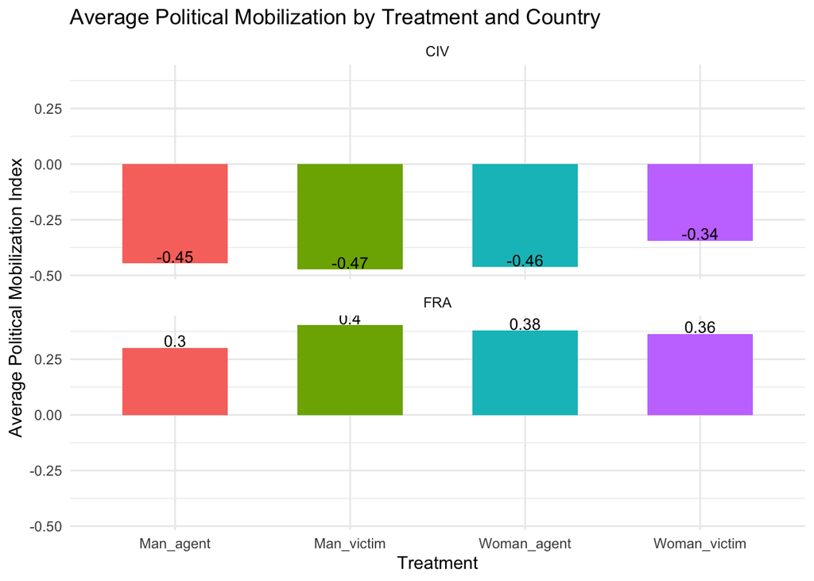

# Secondary hypothesis 2 (S2).

|  | Prefers adaptation finance in poor countries vs. France Unadjusted | Prefers adaptation finance in poor countries vs. France Adjusted | Prefers adaptation finance vs. emergency relief Unadjusted | Prefers adaptation finance vs. emergency relief Adjusted | Prefers gender-based adaptation finance vs. general programming Unadjusted | Prefers gender-based adaptation finance vs. general programming Adjusted | Willingness to sign petition Unadjusted | Willingness to sign petition Adjusted | Clicks to learn more about climate adaptation Unadjusted | Clicks to learn more about climate adaptation Adjusted | Willingness to pay Unadjusted | Willingness to pay Adjusted |
| --- | --- | --- | --- | --- | --- | --- | --- | --- | --- | --- | --- | --- |
| (Intercept) | 0.850*** | 0.499+ | 0.448*** | 0.451+ | 0.338*** | −0.042 | 0.840*** | 0.498* | 0.099*** | 0.046 | 0.832*** | 0.560*** |
|  | (0.018) | (0.297) | (0.025) | (0.233) | (0.024) | (0.333) | (0.019) | (0.241) | (0.015) | (0.091) | (0.019) | (0.122) |
| treatment_female | −0.018 | −0.017 | 0.014 | 0.017 | 0.138*** | 0.159*** | −0.032 | −0.048+ | 0.017 | 0.011 | −0.010 | −0.016 |
|  | (0.026) | (0.027) | (0.035) | (0.038) | (0.034) | (0.036) | (0.027) | (0.028) | (0.022) | (0.024) | (0.027) | (0.027) |
| treatment_victim | −0.007 | −0.005 | −0.008 | −0.006 | −0.018 | −0.029 | 0.005 | 0.009 | 0.016 | 0.021 | −0.080** | −0.081** |
|  | (0.026) | (0.027) | (0.035) | (0.038) | (0.033) | (0.035) | (0.026) | (0.027) | (0.022) | (0.024) | (0.029) | (0.029) |
| treatment_female × treatment_victim | 0.012 | 0.025 | −0.033 | −0.040 | −0.009 | −0.017 | 0.007 | 0.023 | −0.016 | −0.016 | 0.058 | 0.079+ |
|  | (0.037) | (0.038) | (0.050) | (0.054) | (0.048) | (0.051) | (0.038) | (0.039) | (0.031) | (0.034) | (0.040) | (0.041) |
| male |  | 0.034 |  | 0.029 |  | −0.055* |  | 0.070** |  | 0.035+ |  | 0.009 |
|  |  | (0.022) |  | (0.030) |  | (0.028) |  | (0.023) |  | (0.019) |  | (0.023) |
| age25-34 years old |  | 0.013 |  | 0.035 |  | 0.020 |  | 0.022 |  | 0.003 |  | 0.056+ |
|  |  | (0.029) |  | (0.042) |  | (0.039) |  | (0.032) |  | (0.027) |  | (0.031) |
| age35-44 years old |  | 0.019 |  | 0.049 |  | 0.075 |  | 0.038 |  | 0.055+ |  | 0.027 |
|  |  | (0.035) |  | (0.049) |  | (0.047) |  | (0.035) |  | (0.032) |  | (0.037) |
| age45-54 years old |  | −0.018 |  | 0.057 |  | 0.101+ |  | 0.065 |  | 0.103* |  | 0.005 |
|  |  | (0.045) |  | (0.062) |  | (0.058) |  | (0.042) |  | (0.047) |  | (0.046) |
| age55-64 years old |  | −0.089 |  | 0.193+ |  | −0.037 |  | −0.053 |  | 0.100 |  | −0.043 |
|  |  | (0.103) |  | (0.104) |  | (0.098) |  | (0.094) |  | (0.088) |  | (0.091) |
| age75+ years old |  | 0.523*** |  | −0.645*** |  | 0.388* |  | 0.236* |  | 0.047 |  | −1.005*** |
|  |  | (0.126) |  | (0.157) |  | (0.160) |  | (0.116) |  | (0.060) |  | (0.070) |
| employmentOther × |  | 0.082 |  | 0.202 |  | 0.013 |  | −0.014 |  | −0.053 |  | 0.173 |
|  |  | (0.099) |  | (0.141) |  | (0.127) |  | (0.088) |  | (0.102) |  | (0.127) |
| employmentRetired |  | −0.201 |  | 0.077 |  | 0.027 |  | −0.114 |  | −0.021 |  | 0.395** |
|  |  | (0.229) |  | (0.209) |  | (0.201) |  | (0.156) |  | (0.168) |  | (0.123) |
| employmentStudent |  | 0.121 |  | 0.033 |  | −0.023 |  | −0.177* |  | −0.085 |  | 0.216* |
|  |  | (0.086) |  | (0.109) |  | (0.101) |  | (0.078) |  | (0.073) |  | (0.098) |
| employmentUnemployed and looking for work |  | 0.104 |  | −0.028 |  | −0.042 |  | −0.055 |  | −0.054 |  | 0.250* |
|  |  | (0.085) |  | (0.108) |  | (0.100) |  | (0.076) |  | (0.072) |  | (0.097) |
| employmentWorking full-time |  | 0.054 |  | 0.069 |  | −0.035 |  | −0.100 |  | −0.081 |  | 0.242* |
|  |  | (0.082) |  | (0.104) |  | (0.096) |  | (0.072) |  | (0.068) |  | (0.095) |

[output cut: 87 more lines]

+ p < 0.1, * p < 0.05, ** p < 0.01, *** p < 0.001  
Note: 6 climate adpatation outcomes. Run on Ivorian sample. Robust SEs.

|  | Prefers adaptation finance in poor countries vs. France Unadjusted | Prefers adaptation finance in poor countries vs. France Adjusted | Prefers adaptation finance vs. emergency relief Unadjusted | Prefers adaptation finance vs. emergency relief Adjusted | Prefers gender-based adaptation finance vs. general programming Unadjusted | Prefers gender-based adaptation finance vs. general programming Adjusted | Willingness to sign petition Unadjusted | Willingness to sign petition Adjusted | Clicks to learn more about climate adaptation Unadjusted | Clicks to learn more about climate adaptation Adjusted | Willingness to pay Unadjusted | Willingness to pay Adjusted |
| --- | --- | --- | --- | --- | --- | --- | --- | --- | --- | --- | --- | --- |
| (Intercept) | 0.473*** | 0.441 | 0.488*** | 0.468 | 0.266*** | −0.045 | 0.516*** | 0.319 | 0.033*** | −0.142** | 0.483*** | 0.238 |
|  | (0.023) | (0.305) | (0.023) | (0.286) | (0.020) | (0.306) | (0.023) | (0.295) | (0.008) | (0.049) | (0.023) | (0.273) |
| treatment_female | −0.081* | −0.092** | 0.063+ | 0.067* | 0.085** | 0.092** | −0.024 | −0.016 | 0.010 | 0.007 | 0.036 | 0.039 |
|  | (0.032) | (0.032) | (0.032) | (0.033) | (0.030) | (0.030) | (0.032) | (0.031) | (0.012) | (0.013) | (0.032) | (0.031) |
| treatment_victim | −0.074* | −0.079* | 0.022 | 0.025 | 0.005 | 0.023 | −0.011 | −0.007 | 0.011 | 0.013 | 0.008 | 0.008 |
|  | (0.032) | (0.032) | (0.032) | (0.033) | (0.029) | (0.029) | (0.032) | (0.030) | (0.012) | (0.013) | (0.032) | (0.031) |
| treatment_female × treatment_victim | 0.098* | 0.102* | −0.114* | −0.116* | 0.014 | 0.006 | 0.006 | −0.011 | −0.029+ | −0.026 | −0.039 | −0.041 |
|  | (0.045) | (0.045) | (0.046) | (0.046) | (0.042) | (0.042) | (0.046) | (0.043) | (0.017) | (0.018) | (0.046) | (0.044) |
| male |  | −0.042+ |  | 0.037 |  | −0.030 |  | −0.028 |  | 0.001 |  | −0.011 |
|  |  | (0.024) |  | (0.024) |  | (0.022) |  | (0.023) |  | (0.010) |  | (0.023) |
| age25-34 years old |  | −0.104+ |  | 0.162** |  | 0.022 |  | 0.050 |  | 0.005 |  | −0.109+ |
|  |  | (0.057) |  | (0.054) |  | (0.056) |  | (0.056) |  | (0.014) |  | (0.056) |
| age35-44 years old |  | −0.091 |  | 0.187*** |  | 0.046 |  | 0.063 |  | 0.007 |  | −0.051 |
|  |  | (0.057) |  | (0.055) |  | (0.056) |  | (0.057) |  | (0.014) |  | (0.057) |
| age45-54 years old |  | −0.147* |  | 0.200*** |  | 0.022 |  | 0.061 |  | 0.031+ |  | −0.105+ |
|  |  | (0.057) |  | (0.055) |  | (0.056) |  | (0.056) |  | (0.017) |  | (0.056) |
| age55-64 years old |  | −0.090 |  | 0.267*** |  | 0.000 |  | 0.065 |  | 0.043* |  | −0.014 |
|  |  | (0.060) |  | (0.056) |  | (0.057) |  | (0.059) |  | (0.018) |  | (0.058) |
| age65-74 years old |  | −0.051 |  | 0.225** |  | 0.002 |  | 0.049 |  | 0.009 |  | 0.047 |
|  |  | (0.076) |  | (0.075) |  | (0.071) |  | (0.073) |  | (0.029) |  | (0.075) |
| age75+ years old |  | 0.063 |  | 0.366*** |  | −0.074 |  | 0.039 |  | −0.009 |  | 0.128 |
|  |  | (0.100) |  | (0.097) |  | (0.086) |  | (0.097) |  | (0.033) |  | (0.098) |
| employmentOther × |  | −0.228* |  | −0.040 |  | 0.177 |  | −0.029 |  | 0.018 |  | −0.016 |
|  |  | (0.114) |  | (0.129) |  | (0.123) |  | (0.117) |  | (0.048) |  | (0.110) |
| employmentRetired |  | −0.131 |  | −0.097 |  | 0.034 |  | −0.145+ |  | 0.030 |  | −0.045 |
|  |  | (0.083) |  | (0.082) |  | (0.074) |  | (0.077) |  | (0.031) |  | (0.076) |
| employmentStudent |  | −0.110 |  | −0.019 |  | 0.038 |  | −0.121 |  | 0.014 |  | −0.020 |
|  |  | (0.104) |  | (0.106) |  | (0.101) |  | (0.103) |  | (0.029) |  | (0.099) |
| employmentUnemployed and looking for work |  | −0.097 |  | −0.121 |  | 0.001 |  | −0.177* |  | 0.054 |  | −0.039 |
|  |  | (0.090) |  | (0.088) |  | (0.082) |  | (0.088) |  | (0.035) |  | (0.085) |

[output cut: 65 more lines]

+ p < 0.1, * p < 0.05, ** p < 0.01, *** p < 0.001  
Note: 6 climate adpatation outcomes. Run on French sample. Robust SEs.

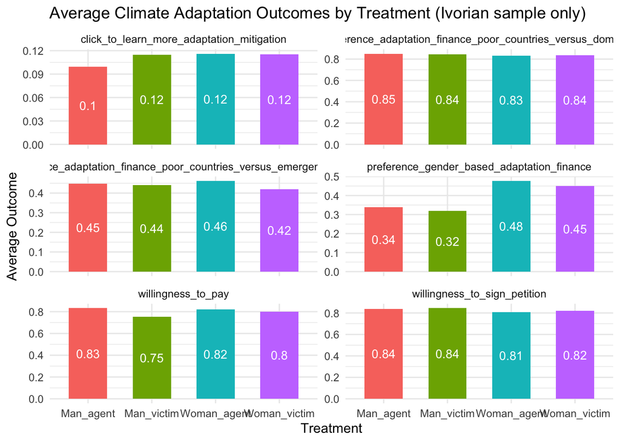

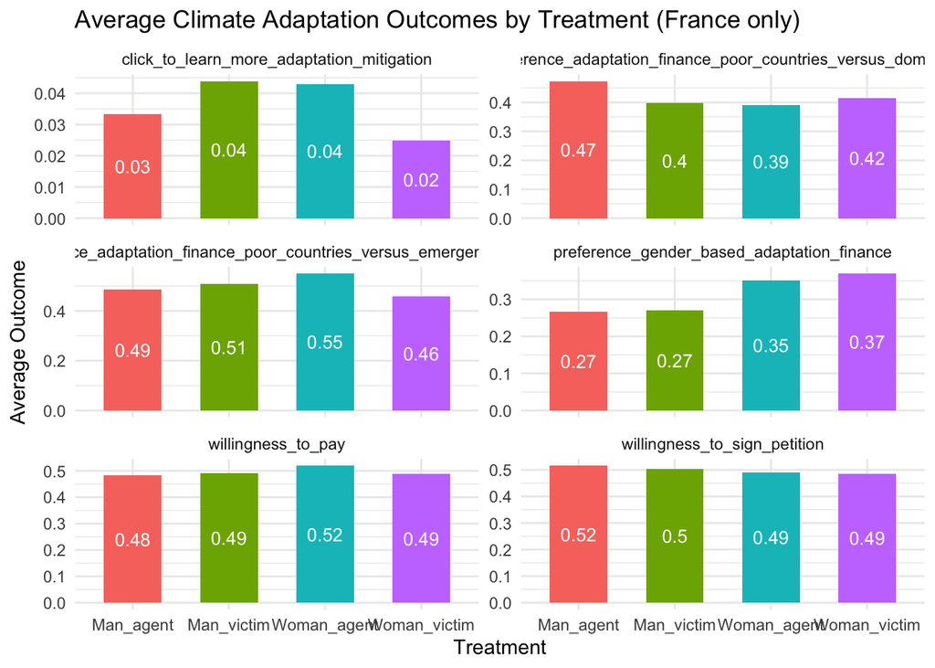

# Exploratory hypotheses.

## Mechanism outcomes

First, in order to probe potential mechanisms underlying our main and secondary hypotheses, we preregister a group of exploratory analyses where we investigate the impact of our treatments (and their interactions) on several psychological and attitudinal outcomes, as well as an open text response on how the treatment made the respondent feel.

|  | Gender paternalism Feminization | Gender paternalism Victimization | Gender paternalism Interaction | Global south paternalism Feminization | Global south paternalism Victimization | Global south paternalism Interaction | People in some parts of the world face more climate consequences Feminization | People in some parts of the world face more climate consequences Victimization | People in some parts of the world face more climate consequences Interaction | Ivory Coast more affected by climate change than France Feminization | Ivory Coast more affected by climate change than France Victimization | Ivory Coast more affected by climate change than France Interaction | Likelihood of climate migration Feminization | Likelihood of climate migration Victimization | Likelihood of climate migration Interaction | Extent to which migration to my country should be decreased Feminization | Extent to which migration to my country should be decreased Victimization | Extent to which migration to my country should be decreased Interaction | Anger/resentment response Feminization | Anger/resentment response Victimization | Anger/resentment response Interaction | Empathetic response Feminization | Empathetic response Victimization | Empathetic response Interaction | Helplessness response Feminization | Helplessness response Victimization | Helplessness response Interaction | Deserving victimhood Feminization | Deserving victimhood Victimization | … |
| --- | --- | --- | --- | --- | --- | --- | --- | --- | --- | --- | --- | --- | --- | --- | --- | --- | --- | --- | --- | --- | --- | --- | --- | --- | --- | --- | --- | --- | --- | --- |
| (Intercept) | 0.755*** | 0.773*** | 0.775*** | 0.833*** | 0.818*** | 0.827*** | 0.579*** | 0.563*** | 0.568*** | 0.693*** | 0.681*** | 0.678*** | 3.794*** | 3.819*** | 3.708*** | 3.333*** | 3.391*** | 3.414*** | 0.069*** | 0.080*** | 0.057*** | 0.792*** | 0.801*** | 0.820*** | 0.139*** | 0.119*** | 0.123*** | 0.614*** | 0.602*** | … |
|  | (0.014) | (0.014) | (0.019) | (0.012) | (0.013) | (0.017) | (0.016) | (0.016) | (0.023) | (0.015) | (0.015) | (0.021) | (0.035) | (0.035) | (0.052) | (0.042) | (0.043) | (0.059) | (0.008) | (0.009) | (0.011) | (0.013) | (0.013) | (0.017) | (0.011) | (0.010) | (0.015) | (0.016) | (0.016) | … |
| treatment_female | 0.018 |  | −0.004 | −0.019 |  | −0.018 | −0.006 |  | −0.009 | −0.003 |  | 0.006 | 0.076 |  | 0.227** | −0.017 |  | −0.047 | 0.031* |  | 0.046** | −0.017 |  | −0.038 | −0.014 |  | −0.009 | −0.032 |  | … |
|  | (0.019) |  | (0.027) | (0.018) |  | (0.025) | (0.023) |  | (0.032) | (0.021) |  | (0.031) | (0.049) |  | (0.070) | (0.061) |  | (0.086) | (0.013) |  | (0.018) | (0.019) |  | (0.026) | (0.015) |  | (0.021) | (0.022) |  | … |
| treatment_victim |  | −0.017 | −0.039 |  | 0.011 | 0.012 |  | 0.026 | 0.023 |  | 0.022 | 0.030 |  | 0.025 | 0.172* |  | −0.131* | −0.161+ |  | 0.007 | 0.022 |  | −0.034+ | −0.055* |  | 0.027+ | 0.032 |  | −0.008 | … |
|  |  | (0.019) | (0.028) |  | (0.018) | (0.024) |  | (0.023) | (0.032) |  | (0.021) | (0.030) |  | (0.049) | (0.070) |  | (0.061) | (0.085) |  | (0.013) | (0.016) |  | (0.019) | (0.026) |  | (0.015) | (0.022) |  | (0.022) | … |
| treatment_victim × treatment_female |  |  | 0.045 |  |  | −0.002 |  |  | 0.006 |  |  | −0.017 |  |  | −0.298** |  |  | 0.062 |  |  | −0.031 |  |  | 0.041 |  |  | −0.011 |  |  | … |
|  |  |  | (0.039) |  |  | (0.035) |  |  | (0.045) |  |  | (0.043) |  |  | (0.098) |  |  | (0.121) |  |  | (0.025) |  |  | (0.037) |  |  | (0.031) |  |  | … |
| R2 | 0.00 | 0.00 | 0.00 | 0.00 | 0.00 | 0.00 | 0.00 | 0.00 | 0.00 | 0.00 | 0.00 | 0.00 | 0.00 | 0.00 | 0.01 | 0.00 | 0.00 | 0.00 | 0.00 | 0.00 | 0.00 | 0.00 | 0.00 | 0.00 | 0.00 | 0.00 | 0.00 | 0.00 | 0.00 | … |
| Num. obs. | 1902 | 1902 | 1902 | 1896 | 1896 | 1896 | 1894 | 1894 | 1894 | 1890 | 1890 | 1890 | 1886 | 1886 | 1886 | 1884 | 1884 | 1884 | 1941 | 1941 | 1941 | 1941 | 1941 | 1941 | 1941 | 1941 | 1941 | 1941 | 1941 | … |
| RMSE | 0.42 | 0.42 | 0.42 | 0.38 | 0.38 | 0.38 | 0.49 | 0.49 | 0.49 | 0.46 | 0.46 | 0.46 | 1.07 | 1.07 | 1.07 | 1.31 | 1.31 | 1.31 | 0.28 | 0.28 | 0.28 | 0.41 | 0.41 | 0.41 | 0.34 | 0.34 | 0.34 | 0.49 | 0.49 | … |

+ p < 0.1, * p < 0.05, ** p < 0.01, *** p < 0.001  
Note: Mechanism outcomes. Run on French sample. Robust SEs.

|  | Gender paternalism Feminization | Gender paternalism Victimization | Gender paternalism Interaction | Global south paternalism Feminization | Global south paternalism Victimization | Global south paternalism Interaction | People in some parts of the world face more climate consequences Feminization | People in some parts of the world face more climate consequences Victimization | People in some parts of the world face more climate consequences Interaction | Ivory Coast more affected by climate change than France Feminization | Ivory Coast more affected by climate change than France Victimization | Ivory Coast more affected by climate change than France Interaction | Likelihood of climate migration Feminization | Likelihood of climate migration Victimization | Likelihood of climate migration Interaction | Extent to which migration to my country should be decreased Feminization | Extent to which migration to my country should be decreased Victimization | Extent to which migration to my country should be decreased Interaction | Anger/resentment response Feminization | Anger/resentment response Victimization | Anger/resentment response Interaction | Empathetic response Feminization | Empathetic response Victimization | Empathetic response Interaction | Helplessness response Feminization | Helplessness response Victimization | Helplessness response Interaction | Deserving victimhood Feminization | Deserving victimhood Victimization | … |
| --- | --- | --- | --- | --- | --- | --- | --- | --- | --- | --- | --- | --- | --- | --- | --- | --- | --- | --- | --- | --- | --- | --- | --- | --- | --- | --- | --- | --- | --- | --- |
| (Intercept) | 0.900*** | 0.907*** | 0.903*** | 0.932*** | 0.929*** | 0.936*** | 0.584*** | 0.596*** | 0.573*** | 0.791*** | 0.776*** | 0.791*** | 3.584*** | 3.554*** | 3.545*** | 2.863*** | 2.910*** | 2.837*** | 0.033*** | 0.044*** | 0.043*** | 0.931*** | 0.902*** | 0.903*** | 0.037*** | 0.054*** | 0.053*** | 0.916*** | 0.907*** | … |
|  | (0.011) | (0.010) | (0.015) | (0.009) | (0.009) | (0.012) | (0.018) | (0.017) | (0.025) | (0.014) | (0.015) | (0.021) | (0.045) | (0.045) | (0.066) | (0.048) | (0.048) | (0.068) | (0.006) | (0.007) | (0.010) | (0.009) | (0.011) | (0.015) | (0.007) | (0.008) | (0.011) | (0.010) | (0.010) | … |
| treatment_female | 0.016 |  | 0.008 | −0.000 |  | −0.015 | 0.034 |  | 0.047 | −0.012 |  | −0.031 | −0.016 |  | 0.018 | 0.114+ |  | 0.143 | 0.011 |  | 0.001 | −0.018 |  | −0.002 | 0.007 |  | 0.001 | 0.004 |  | … |
|  | (0.014) |  | (0.021) | (0.013) |  | (0.018) | (0.024) |  | (0.035) | (0.020) |  | (0.030) | (0.063) |  | (0.090) | (0.067) |  | (0.095) | (0.010) |  | (0.015) | (0.013) |  | (0.021) | (0.010) |  | (0.016) | (0.014) |  | … |
| treatment_victim |  | 0.002 | −0.006 |  | 0.006 | −0.009 |  | 0.009 | 0.022 |  | 0.017 | −0.001 |  | 0.043 | 0.078 |  | 0.022 | 0.050 |  | −0.011 | −0.021 |  | 0.038** | 0.054** |  | −0.027** | −0.033* |  | 0.020 | … |
|  |  | (0.014) | (0.021) |  | (0.013) | (0.018) |  | (0.024) | (0.035) |  | (0.020) | (0.029) |  | (0.063) | (0.091) |  | (0.067) | (0.095) |  | (0.010) | (0.013) |  | (0.013) | (0.018) |  | (0.010) | (0.013) |  | (0.014) | … |
| treatment_victim × treatment_female |  |  | 0.015 |  |  | 0.030 |  |  | −0.027 |  |  | 0.037 |  |  | −0.069 |  |  | −0.057 |  |  | 0.020 |  |  | −0.032 |  |  | 0.013 |  |  | … |
|  |  |  | (0.029) |  |  | (0.025) |  |  | (0.049) |  |  | (0.041) |  |  | (0.125) |  |  | (0.134) |  |  | (0.019) |  |  | (0.027) |  |  | (0.020) |  |  | … |
| R2 | 0.00 | 0.00 | 0.00 | 0.00 | 0.00 | 0.00 | 0.00 | 0.00 | 0.00 | 0.00 | 0.00 | 0.00 | 0.00 | 0.00 | 0.00 | 0.00 | 0.00 | 0.00 | 0.00 | 0.00 | 0.00 | 0.00 | 0.00 | 0.01 | 0.00 | 0.00 | 0.01 | 0.00 | 0.00 | … |
| Num. obs. | 1614 | 1614 | 1614 | 1614 | 1614 | 1614 | 1614 | 1614 | 1614 | 1614 | 1614 | 1614 | 1614 | 1614 | 1614 | 1614 | 1614 | 1614 | 1614 | 1614 | 1614 | 1614 | 1614 | 1614 | 1614 | 1614 | 1614 | 1614 | 1614 | … |
| RMSE | 0.29 | 0.29 | 0.29 | 0.25 | 0.25 | 0.25 | 0.49 | 0.49 | 0.49 | 0.41 | 0.41 | 0.41 | 1.26 | 1.26 | 1.26 | 1.34 | 1.34 | 1.34 | 0.19 | 0.19 | 0.19 | 0.27 | 0.27 | 0.27 | 0.20 | 0.20 | 0.20 | 0.27 | 0.27 | … |

+ p < 0.1, * p < 0.05, ** p < 0.01, *** p < 0.001  
Note: Mechanism outcomes. Run on Ivorian sample. Robust SEs.

## Heterogeneous treatment effects

Second, we probe heterogeneity of treatment effects by conducting subgroup analysis and interaction analyses (between treatment and covariates of interest) with the following covariates: gender, baseline climate beliefs, age, whether or not has children, socioeconomic status, and ambivalent sexism.

### Gender

|  | Political mobilization index | Preference: poor countries vs. France | Preference: adaptation vs. emergency relief | Preference: gender-based vs. general | Willingness to sign petition | Clicks: adaptation and mitigation | Willingness to pay |
| --- | --- | --- | --- | --- | --- | --- | --- |
| (Intercept) | -0.412*** | 0.840*** | 0.417*** | 0.386*** | 0.809*** | 0.075*** | 0.796*** |
|  | (0.076) | (0.021) | (0.028) | (0.027) | (0.022) | (0.015) | (0.023) |
| treatment_female | 0.095 | -0.017 | -0.001 | 0.113** | -0.018 | 0.001 | 0.009 |
|  | (0.105) | (0.029) | (0.039) | (0.039) | (0.031) | (0.021) | (0.031) |
| male | -0.081 | 0.009 | 0.050 | -0.093** | 0.056* | 0.056** | 0.002 |
|  | (0.098) | (0.026) | (0.036) | (0.035) | (0.027) | (0.022) | (0.029) |
| treatment_female × male | -0.062 | 0.010 | -0.008 | 0.032 | -0.012 | 0.008 | 0.012 |
|  | (0.137) | (0.038) | (0.050) | (0.049) | (0.039) | (0.030) | (0.040) |
| R2 | 0.00 | 0.00 | 0.00 | 0.02 | 0.01 | 0.01 | 0.00 |
| Num. obs. | 1599 | 1599 | 1599 | 1599 | 1599 | 1599 | 1599 |
| RMSE | 1.35 | 0.37 | 0.50 | 0.48 | 0.38 | 0.31 | 0.40 |
| (Intercept) | 0.303*** | 0.459*** | 0.467*** | 0.278*** | 0.530*** | 0.038*** | 0.488*** |
|  | (0.062) | (0.023) | (0.023) | (0.021) | (0.023) | (0.009) | (0.023) |
| treatment_female | 0.026 | -0.016 | 0.006 | 0.100*** | -0.026 | -0.005 | 0.001 |
|  | (0.087) | (0.032) | (0.032) | (0.030) | (0.032) | (0.012) | (0.032) |
| male | 0.096 | -0.044 | 0.061+ | -0.019 | -0.039 | 0.001 | -0.002 |
|  | (0.091) | (0.032) | (0.032) | (0.029) | (0.032) | (0.012) | (0.032) |
| treatment_female × male | -0.009 | -0.037 | -0.001 | -0.018 | 0.008 | 0.000 | 0.031 |
|  | (0.130) | (0.045) | (0.046) | (0.042) | (0.046) | (0.017) | (0.046) |
| R2 | 0.00 | 0.01 | 0.00 | 0.01 | 0.00 | 0.00 | 0.00 |
| Num. obs. | 1924 | 1911 | 1912 | 1914 | 1914 | 1907 | 1914 |
| RMSE | 1.42 | 0.49 | 0.50 | 0.46 | 0.50 | 0.19 | 0.50 |

+ p < 0.1, * p < 0.05, ** p < 0.01, *** p < 0.001  
Note: Robust SEs.

|  | Political mobilization index | Preference: poor countries vs. France | Preference: adaptation vs. emergency relief | Preference: gender-based vs. general | Willingness to sign petition | Clicks: adaptation and mitigation | Willingness to pay |
| --- | --- | --- | --- | --- | --- | --- | --- |
| (Intercept) | -0.389*** | 0.842*** | 0.444*** | 0.438*** | 0.789*** | 0.065*** | 0.839*** |
|  | (0.073) | (0.020) | (0.028) | (0.028) | (0.023) | (0.014) | (0.021) |
| treatment_victim | 0.051 | -0.020 | -0.054 | 0.012 | 0.021 | 0.021 | -0.074* |
|  | (0.105) | (0.029) | (0.038) | (0.039) | (0.031) | (0.021) | (0.031) |
| male | -0.111 | -0.000 | 0.018 | -0.050 | 0.059* | 0.072*** | -0.012 |
|  | (0.097) | (0.026) | (0.036) | (0.036) | (0.028) | (0.021) | (0.027) |
| treatment_victim × male | -0.005 | 0.029 | 0.054 | -0.055 | -0.018 | -0.023 | 0.038 |
|  | (0.137) | (0.038) | (0.050) | (0.050) | (0.039) | (0.030) | (0.040) |
| R2 | 0.00 | 0.00 | 0.00 | 0.01 | 0.00 | 0.01 | 0.00 |
| Num. obs. | 1599 | 1599 | 1599 | 1599 | 1599 | 1599 | 1599 |
| RMSE | 1.35 | 0.37 | 0.50 | 0.49 | 0.38 | 0.31 | 0.39 |
| (Intercept) | 0.318*** | 0.458*** | 0.471*** | 0.318*** | 0.489*** | 0.041*** | 0.485*** |
|  | (0.060) | (0.023) | (0.023) | (0.022) | (0.023) | (0.009) | (0.023) |
| treatment_victim | -0.003 | -0.014 | -0.002 | 0.020 | 0.054+ | -0.010 | 0.008 |
|  | (0.087) | (0.032) | (0.032) | (0.030) | (0.032) | (0.012) | (0.032) |
| male | 0.043 | -0.050 | 0.092** | -0.022 | 0.029 | -0.006 | 0.033 |
|  | (0.089) | (0.032) | (0.032) | (0.030) | (0.033) | (0.012) | (0.033) |
| treatment_victim × male | 0.097 | -0.024 | -0.064 | -0.015 | -0.127** | 0.013 | -0.038 |
|  | (0.129) | (0.045) | (0.046) | (0.042) | (0.046) | (0.017) | (0.046) |
| R2 | 0.00 | 0.00 | 0.01 | 0.00 | 0.01 | 0.00 | 0.00 |
| Num. obs. | 1924 | 1911 | 1912 | 1914 | 1914 | 1907 | 1914 |
| RMSE | 1.42 | 0.49 | 0.50 | 0.46 | 0.50 | 0.19 | 0.50 |

+ p < 0.1, * p < 0.05, ** p < 0.01, *** p < 0.001  
Note: Robust SEs.

### Baseline climate beliefs

For the HTEs, we operationalize this as $climate\_beliefs\_binary = 1$ if the respondent says “Moderately”, “A lot”, or “A great deal” to the following question. Other responses are coded as 0. - To what extent do you think climate change already affects or will affect your personal life negatively? Some ways climate change could affect you include irregular rains, more frequent floods, and worsening harvests that make life more expensive and more difficult.

|  | Political mobilization index | Preference: poor countries vs. France | Preference: adaptation vs. emergency relief | Preference: gender-based vs. general | Willingness to sign petition | Clicks: adaptation and mitigation | Willingness to pay |
| --- | --- | --- | --- | --- | --- | --- | --- |
| (Intercept) | -0.195+ | 0.862*** | 0.348*** | 0.448*** | 0.856*** | 0.088*** | 0.790*** |
|  | (0.112) | (0.026) | (0.036) | (0.037) | (0.026) | (0.021) | (0.030) |
| treatment_female | 0.048 | -0.043 | 0.104* | 0.101+ | -0.105* | -0.009 | -0.016 |
|  | (0.158) | (0.039) | (0.052) | (0.053) | (0.042) | (0.029) | (0.044) |
| climate_beliefs_binary | -0.344** | -0.020 | 0.124** | -0.153*** | -0.018 | 0.024 | 0.002 |
|  | (0.123) | (0.030) | (0.041) | (0.041) | (0.030) | (0.025) | (0.035) |
| treatment_female × climate_beliefs_binary | 0.018 | 0.040 | -0.138* | 0.045 | 0.097* | 0.022 | 0.045 |
|  | (0.174) | (0.044) | (0.059) | (0.059) | (0.047) | (0.035) | (0.049) |
| R2 | 0.01 | 0.00 | 0.01 | 0.03 | 0.01 | 0.00 | 0.00 |
| Num. obs. | 1614 | 1614 | 1614 | 1614 | 1614 | 1614 | 1614 |
| RMSE | 1.34 | 0.37 | 0.50 | 0.48 | 0.38 | 0.31 | 0.40 |
| (Intercept) | 1.159*** | 0.392*** | 0.515*** | 0.240*** | 0.327*** | 0.023* | 0.304*** |
|  | (0.108) | (0.037) | (0.038) | (0.033) | (0.036) | (0.012) | (0.035) |
| treatment_female | -0.079 | -0.060 | 0.013 | 0.095* | 0.037 | -0.002 | 0.080 |
|  | (0.146) | (0.051) | (0.053) | (0.048) | (0.051) | (0.016) | (0.050) |
| climate_beliefs_binary | -0.980*** | 0.054 | -0.020 | 0.035 | 0.222*** | 0.018 | 0.223*** |
|  | (0.118) | (0.041) | (0.042) | (0.036) | (0.040) | (0.014) | (0.040) |
| treatment_female × climate_beliefs_binary | 0.101 | 0.036 | -0.010 | -0.003 | -0.068 | -0.004 | -0.074 |
|  | (0.162) | (0.057) | (0.059) | (0.053) | (0.057) | (0.019) | (0.056) |
| R2 | 0.06 | 0.00 | 0.00 | 0.01 | 0.02 | 0.00 | 0.02 |
| Num. obs. | 1925 | 1912 | 1913 | 1915 | 1915 | 1908 | 1915 |
| RMSE | 1.37 | 0.49 | 0.50 | 0.46 | 0.49 | 0.19 | 0.49 |

+ p < 0.1, * p < 0.05, ** p < 0.01, *** p < 0.001  
Note: Robust SEs.

|  | Political mobilization index | Preference: poor countries vs. France | Preference: adaptation vs. emergency relief | Preference: gender-based vs. general | Willingness to sign petition | Clicks: adaptation and mitigation | Willingness to pay |
| --- | --- | --- | --- | --- | --- | --- | --- |
| (Intercept) | -0.305** | 0.858*** | 0.395*** | 0.500*** | 0.827*** | 0.068*** | 0.815*** |
|  | (0.118) | (0.028) | (0.039) | (0.039) | (0.030) | (0.020) | (0.031) |
| treatment_victim | 0.243 | -0.031 | 0.008 | -0.005 | -0.041 | 0.029 | -0.060 |
|  | (0.159) | (0.039) | (0.052) | (0.053) | (0.042) | (0.029) | (0.043) |
| climate_beliefs_binary | -0.188 | -0.022 | 0.075+ | -0.115** | -0.005 | 0.050* | 0.015 |
|  | (0.129) | (0.031) | (0.043) | (0.044) | (0.033) | (0.024) | (0.034) |
| treatment_victim × climate_beliefs_binary | -0.268 | 0.039 | -0.039 | -0.029 | 0.066 | -0.026 | 0.013 |
|  | (0.175) | (0.044) | (0.059) | (0.060) | (0.047) | (0.034) | (0.049) |
| R2 | 0.01 | 0.00 | 0.00 | 0.01 | 0.00 | 0.00 | 0.00 |
| Num. obs. | 1614 | 1614 | 1614 | 1614 | 1614 | 1614 | 1614 |
| RMSE | 1.34 | 0.37 | 0.50 | 0.49 | 0.38 | 0.31 | 0.40 |
| (Intercept) | 1.062*** | 0.360*** | 0.481*** | 0.270*** | 0.328*** | 0.037** | 0.354*** |
|  | (0.097) | (0.035) | (0.036) | (0.032) | (0.034) | (0.014) | (0.035) |
| treatment_victim | 0.119 | 0.002 | 0.085 | 0.042 | 0.039 | -0.031* | -0.019 |
|  | (0.146) | (0.051) | (0.053) | (0.048) | (0.051) | (0.015) | (0.051) |
| climate_beliefs_binary | -0.903*** | 0.092* | 0.046 | 0.048 | 0.219*** | 0.001 | 0.183*** |
|  | (0.109) | (0.039) | (0.041) | (0.037) | (0.039) | (0.016) | (0.039) |
| treatment_victim × climate_beliefs_binary | -0.060 | -0.036 | -0.146* | -0.037 | -0.066 | 0.033+ | 0.004 |
|  | (0.162) | (0.057) | (0.059) | (0.054) | (0.057) | (0.018) | (0.057) |
| R2 | 0.07 | 0.00 | 0.00 | 0.00 | 0.02 | 0.00 | 0.02 |
| Num. obs. | 1925 | 1912 | 1913 | 1915 | 1915 | 1908 | 1915 |
| RMSE | 1.37 | 0.49 | 0.50 | 0.46 | 0.49 | 0.19 | 0.49 |

+ p < 0.1, * p < 0.05, ** p < 0.01, *** p < 0.001  
Note: Robust SEs.

### Age

For the HTEs, we operationalize this as $above\_median\_age = 1$ if the respondent’s age is above the median age category. Other responses are coded as 0.

|  | Political mobilization index | Preference: poor countries vs. France | Preference: adaptation vs. emergency relief | Preference: gender-based vs. general | Willingness to sign petition | Clicks: adaptation and mitigation | Willingness to pay |
| --- | --- | --- | --- | --- | --- | --- | --- |
| (Intercept) | -0.453*** | 0.848*** | 0.427*** | 0.331*** | 0.838*** | 0.099*** | 0.793*** |
|  | (0.050) | (0.013) | (0.019) | (0.018) | (0.014) | (0.011) | (0.015) |
| treatment_female | 0.116 | -0.010 | 0.010 | 0.121*** | -0.037+ | 0.003 | 0.017 |
|  | (0.071) | (0.019) | (0.026) | (0.025) | (0.020) | (0.016) | (0.021) |
| above_median_age | -0.069 | -0.017 | 0.164** | -0.018 | 0.041 | 0.082+ | -0.010 |
|  | (0.170) | (0.043) | (0.057) | (0.054) | (0.039) | (0.044) | (0.048) |
| treatment_female × above_median_age | -0.557** | -0.019 | -0.124 | 0.124 | 0.076 | 0.048 | 0.026 |
|  | (0.214) | (0.063) | (0.081) | (0.079) | (0.051) | (0.064) | (0.065) |
| R2 | 0.01 | 0.00 | 0.01 | 0.02 | 0.01 | 0.01 | 0.00 |
| Num. obs. | 1614 | 1614 | 1614 | 1614 | 1614 | 1614 | 1614 |
| RMSE | 1.34 | 0.37 | 0.50 | 0.48 | 0.38 | 0.31 | 0.40 |
| (Intercept) | 0.264*** | 0.494*** | 0.489*** | 0.311*** | 0.580*** | 0.029*** | 0.531*** |
|  | (0.067) | (0.025) | (0.025) | (0.023) | (0.024) | (0.008) | (0.024) |
| treatment_female | -0.077 | -0.030 | -0.052 | 0.069* | -0.051 | -0.009 | 0.018 |
|  | (0.097) | (0.035) | (0.035) | (0.033) | (0.035) | (0.011) | (0.035) |
| above_median_age | 0.154+ | -0.102** | 0.016 | -0.075** | -0.124*** | 0.017 | -0.077* |
|  | (0.092) | (0.032) | (0.033) | (0.029) | (0.032) | (0.012) | (0.032) |
| treatment_female × above_median_age | 0.165 | -0.003 | 0.099* | 0.041 | 0.053 | 0.007 | -0.003 |
|  | (0.130) | (0.046) | (0.046) | (0.043) | (0.046) | (0.017) | (0.046) |
| R2 | 0.01 | 0.01 | 0.01 | 0.01 | 0.01 | 0.00 | 0.01 |
| Num. obs. | 1925 | 1912 | 1913 | 1915 | 1915 | 1908 | 1915 |
| RMSE | 1.41 | 0.49 | 0.50 | 0.46 | 0.50 | 0.19 | 0.50 |

+ p < 0.1, * p < 0.05, ** p < 0.01, *** p < 0.001  
Note: Robust SEs.

|  | Political mobilization index | Preference: poor countries vs. France | Preference: adaptation vs. emergency relief | Preference: gender-based vs. general | Willingness to sign petition | Clicks: adaptation and mitigation | Willingness to pay |
| --- | --- | --- | --- | --- | --- | --- | --- |
| (Intercept) | -0.421*** | 0.845*** | 0.442*** | 0.402*** | 0.814*** | 0.094*** | 0.825*** |
|  | (0.050) | (0.013) | (0.018) | (0.018) | (0.014) | (0.011) | (0.014) |
| treatment_victim | 0.054 | -0.004 | -0.020 | -0.019 | 0.010 | 0.012 | -0.048* |
|  | (0.071) | (0.019) | (0.026) | (0.026) | (0.020) | (0.016) | (0.021) |
| above_median_age | -0.353* | -0.042 | 0.137* | 0.072 | 0.093* | 0.143** | 0.017 |
|  | (0.161) | (0.048) | (0.060) | (0.060) | (0.036) | (0.050) | (0.044) |
| treatment_victim × above_median_age | -0.005 | 0.029 | -0.064 | -0.047 | -0.025 | -0.066 | -0.020 |
|  | (0.216) | (0.063) | (0.082) | (0.081) | (0.051) | (0.065) | (0.064) |
| R2 | 0.01 | 0.00 | 0.00 | 0.00 | 0.00 | 0.01 | 0.00 |
| Num. obs. | 1614 | 1614 | 1614 | 1614 | 1614 | 1614 | 1614 |
| RMSE | 1.35 | 0.37 | 0.50 | 0.49 | 0.38 | 0.31 | 0.40 |
| (Intercept) | 0.261*** | 0.510*** | 0.469*** | 0.345*** | 0.557*** | 0.029*** | 0.540*** |
|  | (0.065) | (0.025) | (0.025) | (0.023) | (0.024) | (0.008) | (0.025) |
| treatment_victim | -0.070 | -0.061+ | -0.010 | -0.001 | -0.003 | -0.009 | 0.000 |
|  | (0.097) | (0.035) | (0.035) | (0.033) | (0.035) | (0.011) | (0.035) |
| above_median_age | 0.138 | -0.136*** | 0.088** | -0.066* | -0.094** | 0.016 | -0.069* |
|  | (0.089) | (0.032) | (0.033) | (0.030) | (0.033) | (0.012) | (0.033) |
| treatment_victim × above_median_age | 0.193 | 0.064 | -0.045 | 0.025 | -0.008 | 0.010 | -0.018 |
|  | (0.130) | (0.046) | (0.046) | (0.043) | (0.046) | (0.017) | (0.046) |
| R2 | 0.01 | 0.01 | 0.01 | 0.00 | 0.01 | 0.00 | 0.01 |
| Num. obs. | 1925 | 1912 | 1913 | 1915 | 1915 | 1908 | 1915 |
| RMSE | 1.41 | 0.49 | 0.50 | 0.46 | 0.50 | 0.19 | 0.50 |

+ p < 0.1, * p < 0.05, ** p < 0.01, *** p < 0.001  
Note: Robust SEs.

### Has children

|  | Political mobilization index | Preference: poor countries vs. France | Preference: adaptation vs. emergency relief | Preference: gender-based vs. general | Willingness to sign petition | Clicks: adaptation and mitigation | Willingness to pay |
| --- | --- | --- | --- | --- | --- | --- | --- |
| (Intercept) | -0.162* | 0.852*** | 0.392*** | 0.264*** | 0.815*** | 0.101*** | 0.732*** |
|  | (0.067) | (0.018) | (0.024) | (0.022) | (0.019) | (0.015) | (0.022) |
| treatment_female | 0.008 | -0.037 | 0.032 | 0.130*** | -0.083** | 0.007 | 0.040 |
|  | (0.092) | (0.026) | (0.034) | (0.032) | (0.029) | (0.021) | (0.030) |
| has_children | -0.612*** | -0.012 | 0.107** | 0.134*** | 0.056* | 0.013 | 0.124*** |
|  | (0.094) | (0.026) | (0.035) | (0.033) | (0.026) | (0.022) | (0.028) |
| treatment_female × has_children | 0.084 | 0.052 | -0.071 | 0.012 | 0.116** | 0.003 | -0.040 |
|  | (0.132) | (0.036) | (0.049) | (0.048) | (0.037) | (0.031) | (0.039) |
| R2 | 0.05 | 0.00 | 0.01 | 0.04 | 0.03 | 0.00 | 0.02 |
| Num. obs. | 1614 | 1614 | 1614 | 1614 | 1614 | 1614 | 1614 |
| RMSE | 1.32 | 0.37 | 0.50 | 0.48 | 0.37 | 0.31 | 0.40 |
| (Intercept) | 0.417*** | 0.442*** | 0.524*** | 0.258*** | 0.488*** | 0.033*** | 0.455*** |
|  | (0.078) | (0.027) | (0.028) | (0.024) | (0.028) | (0.010) | (0.027) |
| treatment_female | 0.012 | -0.003 | -0.044 | 0.086* | -0.036 | -0.010 | 0.024 |
|  | (0.113) | (0.040) | (0.040) | (0.036) | (0.040) | (0.013) | (0.040) |
| has_children | -0.100 | -0.010 | -0.039 | 0.017 | 0.033 | 0.008 | 0.050 |
|  | (0.096) | (0.034) | (0.034) | (0.030) | (0.034) | (0.013) | (0.034) |
| treatment_female × has_children | 0.015 | -0.042 | 0.073 | 0.009 | 0.020 | 0.008 | -0.013 |
|  | (0.138) | (0.048) | (0.049) | (0.045) | (0.049) | (0.017) | (0.049) |
| R2 | 0.00 | 0.00 | 0.00 | 0.01 | 0.00 | 0.00 | 0.00 |
| Num. obs. | 1925 | 1912 | 1913 | 1915 | 1915 | 1908 | 1915 |
| RMSE | 1.42 | 0.49 | 0.50 | 0.46 | 0.50 | 0.19 | 0.50 |

+ p < 0.1, * p < 0.05, ** p < 0.01, *** p < 0.001  
Note: Robust SEs.

|  | Political mobilization index | Preference: poor countries vs. France | Preference: adaptation vs. emergency relief | Preference: gender-based vs. general | Willingness to sign petition | Clicks: adaptation and mitigation | Willingness to pay |
| --- | --- | --- | --- | --- | --- | --- | --- |
| (Intercept) | -0.166* | 0.841*** | 0.419*** | 0.333*** | 0.778*** | 0.113*** | 0.793*** |
|  | (0.065) | (0.018) | (0.024) | (0.023) | (0.020) | (0.016) | (0.020) |
| treatment_victim | 0.018 | -0.015 | -0.022 | -0.003 | -0.011 | -0.017 | -0.080** |
|  | (0.092) | (0.026) | (0.034) | (0.033) | (0.029) | (0.021) | (0.030) |
| has_children | -0.600*** | -0.000 | 0.074* | 0.158*** | 0.094*** | -0.011 | 0.071** |
|  | (0.093) | (0.026) | (0.035) | (0.035) | (0.027) | (0.022) | (0.027) |
| treatment_victim × has_children | 0.059 | 0.029 | -0.006 | -0.040 | 0.042 | 0.051 | 0.062 |
|  | (0.132) | (0.036) | (0.049) | (0.048) | (0.037) | (0.031) | (0.039) |
| R2 | 0.04 | 0.00 | 0.01 | 0.02 | 0.02 | 0.00 | 0.02 |
| Num. obs. | 1614 | 1614 | 1614 | 1614 | 1614 | 1614 | 1614 |
| RMSE | 1.32 | 0.37 | 0.50 | 0.48 | 0.37 | 0.31 | 0.39 |
| (Intercept) | 0.409*** | 0.446*** | 0.497*** | 0.318*** | 0.455*** | 0.029** | 0.452*** |
|  | (0.077) | (0.028) | (0.028) | (0.026) | (0.028) | (0.009) | (0.028) |
| treatment_victim | 0.028 | -0.010 | 0.013 | -0.039 | 0.030 | -0.000 | 0.027 |
|  | (0.113) | (0.040) | (0.040) | (0.036) | (0.040) | (0.013) | (0.040) |
| has_children | -0.104 | -0.019 | 0.032 | -0.016 | 0.072* | 0.014 | 0.073* |
|  | (0.095) | (0.034) | (0.035) | (0.032) | (0.034) | (0.012) | (0.034) |
| treatment_victim × has_children | 0.023 | -0.024 | -0.071 | 0.078+ | -0.059 | -0.005 | -0.057 |
|  | (0.138) | (0.048) | (0.049) | (0.045) | (0.049) | (0.017) | (0.049) |
| R2 | 0.00 | 0.00 | 0.00 | 0.00 | 0.00 | 0.00 | 0.00 |
| Num. obs. | 1925 | 1912 | 1913 | 1915 | 1915 | 1908 | 1915 |
| RMSE | 1.42 | 0.49 | 0.50 | 0.46 | 0.50 | 0.19 | 0.50 |

+ p < 0.1, * p < 0.05, ** p < 0.01, *** p < 0.001  
Note: Robust SEs.

### Socioeconomic status

For the HTEs, we operationalize this as $above\_median\_edu = 1$ if the respondent’s education is above the median level, 0 otherwise.

```
##
##                                                         0    1
##   Informal education only (including Koranic school)   35    0
##   No formal education                                  43    0
##   Post-university                                       0  213
##   Primary school                                       68    0
##   Secondary school                                   1214    0
##   University                                         1982    0
```

|  | Political mobilization index | Preference: poor countries vs. France | Preference: adaptation vs. emergency relief | Preference: gender-based vs. general | Willingness to sign petition | Clicks: adaptation and mitigation | Willingness to pay |
| --- | --- | --- | --- | --- | --- | --- | --- |
| (Intercept) | -0.458*** | 0.844*** | 0.444*** | 0.326*** | 0.841*** | 0.105*** | 0.794*** |
|  | (0.049) | (0.013) | (0.018) | (0.017) | (0.013) | (0.011) | (0.015) |
| treatment_female | 0.072 | -0.005 | -0.012 | 0.141*** | -0.032+ | 0.009 | 0.016 |
|  | (0.069) | (0.019) | (0.025) | (0.025) | (0.019) | (0.016) | (0.020) |
| above_median_edu | -0.045 | 0.054 | -0.008 | 0.058 | 0.031 | 0.049 | -0.051 |
|  | (0.222) | (0.051) | (0.082) | (0.081) | (0.056) | (0.060) | (0.072) |
| treatment_female × above_median_edu | -0.269 | -0.130 | 0.171 | -0.145 | 0.065 | -0.020 | 0.074 |
|  | (0.316) | (0.085) | (0.114) | (0.112) | (0.074) | (0.082) | (0.094) |
| R2 | 0.00 | 0.00 | 0.00 | 0.02 | 0.00 | 0.00 | 0.00 |
| Num. obs. | 1614 | 1614 | 1614 | 1614 | 1614 | 1614 | 1614 |
| RMSE | 1.35 | 0.37 | 0.50 | 0.48 | 0.38 | 0.31 | 0.40 |
| (Intercept) | 0.376*** | 0.432*** | 0.491*** | 0.268*** | 0.500*** | 0.037*** | 0.474*** |
|  | (0.047) | (0.017) | (0.017) | (0.015) | (0.017) | (0.006) | (0.017) |
| treatment_female | 0.013 | -0.028 | 0.003 | 0.091*** | -0.011 | -0.003 | 0.028 |
|  | (0.067) | (0.023) | (0.024) | (0.022) | (0.024) | (0.009) | (0.024) |
| above_median_edu | -0.345+ | 0.052 | 0.116+ | 0.005 | 0.142* | 0.024 | 0.192** |
|  | (0.187) | (0.064) | (0.063) | (0.057) | (0.061) | (0.030) | (0.061) |
| treatment_female × above_median_edu | 0.079 | -0.057 | 0.021 | 0.021 | -0.154+ | -0.027 | -0.172+ |
|  | (0.267) | (0.090) | (0.089) | (0.085) | (0.089) | (0.038) | (0.089) |
| R2 | 0.00 | 0.00 | 0.00 | 0.01 | 0.00 | 0.00 | 0.01 |
| Num. obs. | 1925 | 1912 | 1913 | 1915 | 1915 | 1908 | 1915 |
| RMSE | 1.42 | 0.49 | 0.50 | 0.46 | 0.50 | 0.19 | 0.50 |

+ p < 0.1, * p < 0.05, ** p < 0.01, *** p < 0.001  
Note: Robust SEs.

|  | Political mobilization index | Preference: poor countries vs. France | Preference: adaptation vs. emergency relief | Preference: gender-based vs. general | Willingness to sign petition | Clicks: adaptation and mitigation | Willingness to pay |
| --- | --- | --- | --- | --- | --- | --- | --- |
| (Intercept) | -0.441*** | 0.837*** | 0.451*** | 0.412*** | 0.817*** | 0.106*** | 0.824*** |
|  | (0.049) | (0.013) | (0.018) | (0.018) | (0.014) | (0.011) | (0.014) |
| treatment_victim | 0.038 | 0.008 | -0.025 | -0.029 | 0.015 | 0.007 | -0.042* |
|  | (0.069) | (0.019) | (0.025) | (0.025) | (0.019) | (0.016) | (0.020) |
| above_median_edu | -0.246 | 0.072 | 0.072 | -0.072 | 0.115** | 0.030 | 0.063 |
|  | (0.205) | (0.046) | (0.078) | (0.074) | (0.041) | (0.054) | (0.050) |
| treatment_victim × above_median_edu | 0.141 | -0.187* | 0.016 | 0.120 | -0.109 | 0.019 | -0.169+ |
|  | (0.320) | (0.088) | (0.116) | (0.113) | (0.075) | (0.082) | (0.094) |
| R2 | 0.00 | 0.00 | 0.00 | 0.00 | 0.00 | 0.00 | 0.01 |
| Num. obs. | 1614 | 1614 | 1614 | 1614 | 1614 | 1614 | 1614 |
| RMSE | 1.35 | 0.37 | 0.50 | 0.49 | 0.38 | 0.31 | 0.40 |
| (Intercept) | 0.368*** | 0.428*** | 0.509*** | 0.302*** | 0.495*** | 0.037*** | 0.494*** |
|  | (0.047) | (0.017) | (0.017) | (0.016) | (0.017) | (0.006) | (0.017) |
| treatment_victim | 0.027 | -0.019 | -0.033 | 0.021 | -0.000 | -0.003 | -0.011 |
|  | (0.067) | (0.023) | (0.024) | (0.022) | (0.024) | (0.009) | (0.024) |
| above_median_edu | -0.367* | 0.065 | 0.118* | 0.071 | 0.110+ | 0.017 | 0.093 |
|  | (0.157) | (0.060) | (0.059) | (0.058) | (0.059) | (0.027) | (0.060) |
| treatment_victim × above_median_edu | 0.149 | -0.099 | 0.014 | -0.127 | -0.105 | -0.015 | 0.031 |
|  | (0.280) | (0.090) | (0.090) | (0.085) | (0.091) | (0.037) | (0.090) |
| R2 | 0.00 | 0.00 | 0.01 | 0.00 | 0.00 | 0.00 | 0.00 |
| Num. obs. | 1925 | 1912 | 1913 | 1915 | 1915 | 1908 | 1915 |
| RMSE | 1.42 | 0.49 | 0.50 | 0.46 | 0.50 | 0.19 | 0.50 |

+ p < 0.1, * p < 0.05, ** p < 0.01, *** p < 0.001  
Note: Robust SEs.

For the HTEs, we use the $ambivalent\_sexism\_index$.

|  | Political mobilization index | Preference: poor countries vs. France | Preference: adaptation vs. emergency relief | Preference: gender-based vs. general | Willingness to sign petition | Clicks: adaptation and mitigation | Willingness to pay |
| --- | --- | --- | --- | --- | --- | --- | --- |
| (Intercept) | 0.770* | 0.525*** | 0.814*** | 0.224* | 0.751*** | -0.007 | 0.577*** |
|  | (0.303) | (0.086) | (0.105) | (0.101) | (0.075) | (0.064) | (0.085) |
| treatment_female | 0.302 | 0.121 | -0.367** | -0.004 | -0.078 | 0.084 | 0.244* |
|  | (0.413) | (0.116) | (0.142) | (0.141) | (0.112) | (0.087) | (0.112) |
| ambivalent_sexism_index | -0.338*** | 0.088*** | -0.102*** | 0.029 | 0.025 | 0.031+ | 0.059** |
|  | (0.082) | (0.023) | (0.028) | (0.027) | (0.020) | (0.018) | (0.023) |
| treatment_female × ambivalent_sexism_index | -0.066 | -0.036 | 0.100** | 0.038 | 0.013 | -0.021 | -0.062* |
|  | (0.112) | (0.030) | (0.038) | (0.038) | (0.030) | (0.024) | (0.030) |
| R2 | 0.03 | 0.02 | 0.01 | 0.02 | 0.00 | 0.00 | 0.00 |
| Num. obs. | 1614 | 1614 | 1614 | 1614 | 1614 | 1614 | 1614 |
| RMSE | 1.33 | 0.36 | 0.49 | 0.48 | 0.38 | 0.31 | 0.40 |
| (Intercept) | 1.467*** | 0.314*** | 0.682*** | -0.009 | 0.186* | 0.042 | 0.257** |
|  | (0.260) | (0.088) | (0.088) | (0.077) | (0.089) | (0.037) | (0.087) |
| treatment_female | 0.073 | 0.045 | -0.009 | -0.067 | 0.070 | -0.048 | 0.139 |
|  | (0.389) | (0.126) | (0.126) | (0.115) | (0.127) | (0.050) | (0.125) |
| ambivalent_sexism_index | -0.333*** | 0.036 | -0.055* | 0.083*** | 0.097*** | -0.001 | 0.069** |
|  | (0.077) | (0.026) | (0.026) | (0.023) | (0.026) | (0.011) | (0.025) |
| treatment_female × ambivalent_sexism_index | -0.016 | -0.023 | 0.004 | 0.048 | -0.027 | 0.013 | -0.036 |
|  | (0.115) | (0.037) | (0.037) | (0.034) | (0.037) | (0.015) | (0.037) |
| R2 | 0.02 | 0.00 | 0.00 | 0.03 | 0.01 | 0.00 | 0.00 |
| Num. obs. | 1925 | 1912 | 1913 | 1915 | 1915 | 1908 | 1915 |
| RMSE | 1.40 | 0.49 | 0.50 | 0.46 | 0.50 | 0.19 | 0.50 |

+ p < 0.1, * p < 0.05, ** p < 0.01, *** p < 0.001  
Note: Robust SEs.

|  | Political mobilization index | Preference: poor countries vs. France | Preference: adaptation vs. emergency relief | Preference: gender-based vs. general | Willingness to sign petition | Clicks: adaptation and mitigation | Willingness to pay |
| --- | --- | --- | --- | --- | --- | --- | --- |
| (Intercept) | 0.848** | 0.562*** | 0.635*** | 0.174+ | 0.747*** | 0.077 | 0.741*** |
|  | (0.280) | (0.079) | (0.100) | (0.100) | (0.082) | (0.059) | (0.071) |
| treatment_victim | 0.156 | 0.056 | -0.027 | 0.092 | -0.077 | -0.081 | -0.057 |
|  | (0.411) | (0.116) | (0.141) | (0.141) | (0.114) | (0.087) | (0.112) |
| ambivalent_sexism_index | -0.355*** | 0.076*** | -0.049+ | 0.064* | 0.021 | 0.008 | 0.024 |
|  | (0.076) | (0.021) | (0.027) | (0.027) | (0.022) | (0.016) | (0.019) |
| treatment_victim × ambivalent_sexism_index | -0.036 | -0.015 | -0.000 | -0.031 | 0.024 | 0.024 | 0.002 |
|  | (0.111) | (0.030) | (0.038) | (0.038) | (0.030) | (0.024) | (0.030) |
| R2 | 0.03 | 0.02 | 0.00 | 0.01 | 0.00 | 0.00 | 0.01 |
| Num. obs. | 1614 | 1614 | 1614 | 1614 | 1614 | 1614 | 1614 |
| RMSE | 1.33 | 0.36 | 0.50 | 0.49 | 0.38 | 0.31 | 0.40 |
| (Intercept) | 1.130*** | 0.380*** | 0.659*** | -0.114 | 0.112 | 0.021 | 0.281** |
|  | (0.289) | (0.096) | (0.095) | (0.085) | (0.096) | (0.030) | (0.095) |
| treatment_victim | 0.668+ | -0.076 | 0.040 | 0.130 | 0.194 | -0.003 | 0.079 |
|  | (0.389) | (0.127) | (0.127) | (0.116) | (0.128) | (0.049) | (0.126) |
| ambivalent_sexism_index | -0.234** | 0.016 | -0.041 | 0.125*** | 0.116*** | 0.005 | 0.065* |
|  | (0.085) | (0.028) | (0.028) | (0.025) | (0.028) | (0.009) | (0.027) |
| treatment_victim × ambivalent_sexism_index | -0.192+ | 0.015 | -0.023 | -0.033 | -0.059 | -0.000 | -0.026 |
|  | (0.115) | (0.037) | (0.037) | (0.034) | (0.037) | (0.015) | (0.037) |
| R2 | 0.02 | 0.00 | 0.01 | 0.02 | 0.01 | 0.00 | 0.00 |
| Num. obs. | 1925 | 1912 | 1913 | 1915 | 1915 | 1908 | 1915 |
| RMSE | 1.40 | 0.49 | 0.50 | 0.46 | 0.50 | 0.19 | 0.50 |

+ p < 0.1, * p < 0.05, ** p < 0.01, *** p < 0.001  
Note: Robust SEs.

## Analysis of open text outcomes

We will come back to this after soliciting feedback on how to analyze the responses. For now, we randomly select 50 responses from each treatment category and compare them.

### Comparing female to male treatments

| French - Male treatment | Random Emotional Responses by Sample and Treatment French - Female treatment | Random Emotional Responses by Sample and Treatment Ivorian - Male treatment | Random Emotional Responses by Sample and Treatment Ivorian - Female treatment | Random Emotional Responses by Sample and Treatment |
| --- | --- | --- | --- | --- |
| Désolation après le dégâts causés par le changement climatique : inondation, incendie | La tristesse | De la peine, de la tristesse | Très ému |  |
| La misère du monde | Peine | الشعور والقلق | J’étais très emerveillé de voir la femme tenir cette pancarte en guise de sensibilisation. |  |
| Rien | De la tristesse | Un choc et de la compassion | It sad and emotionally touching,it feels like am the one been affected by this kind of factor |  |
| Rien de particulier | Tristesse | Un pincement au cœur | Des frissons de voir une femme dévouée |  |
| rien de particulier | pourquoi une femme le changement climatique touche tout le monde | le changement climatique affecte de nombreuse personnes notamment les personne qui vivent dans les zones rural le gouvernement ne faire rien pour y changer la plusieurs catastrophe naturel s’y produis… | Je sais pas |  |
| Ce que l’ont voit régulièrement au journal télévisé. De la souffrance | De la peine | de la tristesse et la désolation pour les personnes vivantes dans cet endroit. les conditions de vie sont devenues difficiles à cause du changement climatique | De la peine et de la tristesse |  |
| De la tristesse | De l’inquiétude | Personnes souffrant de dommages climatiques | C’est un sentiment de tristesse de savoir que d’autres personnes sont dévasté par le changement climatique |  |
| Pitié | triste | Un sentiment de colère et de pitié. | La peine |  |
| De la paix | De la pitié | Nous devons protéger la nature pour le bien de Tous | De l’émoi |  |
| On peut ressentir une personne dans le besoin | de la fierté pour cette femme qui se bat pour une cause noble | De la compation | J’ai ressenti de la tristesse. Beaucoup de douleurs au niveau de la gente féminine |  |
| De l’empathie | de la peine | De la tristesse face à ce changement, les inondations et les famines don’t ses population endure face à ce changement | Espérant pouvoir l’aider |  |
| Rien de spécial | Sa me semblait triste | يتأثر البشر بالتغيرات في درجة الحرارة | Rien |  |
| Compassion | on retrait sera approuvé par un modérateur sous peu. Cela ne prend généralement que quelques minutes. Pour un premier retrait, l’approbation se fait habituellement dans l’heure qui s | De la compassion | Une mélancolie |  |
| Émotion | Je sais pas | De la peine | De la peine |  |
| L’envie d’aider | Que le changement climatique peut engendrer beaucoup de difficultés | De l’espoir | de la tristesse et de l’empathie |  |
| rien du tout | DE L’ADMIRATION pour cette femme | Mal au cœur | Une femme souffrant de la climatisation |  |
| Rien en particulier | Solidarité, compréhension | le changement climatique peut occasionner l’exode rurale avec son corolaire de maladie, et autres effets negatifs | La petitesse de l’homme face à la nature |  |
| C’est une tristesse de plus, une cause de plus du réchauffement climatique | Il faut faire des efforts contre le réchauffement climatique | Je me suis sentir incapable de lui venir en aide | J’étais contente de voir une femme lutter contre le changement climatique |  |
| Image montrant la mauvaise image pour la nature et surtout l humaine | tristesse | Une profonde tristesse et un désir de changement | EN VOYANT L IMAGE SUR LA PHOTO J AI RESSENTI DE LA PITIÉ POUR CETTE DAME |  |
| Action | Empatie | Un sentiment d’impuissance | De l’empathie |  |
| Triste | de la tristesse | J’ai eu très mal | J’ai mal au cœur |  |
| De la tristesse et un sentiment d’impuissance. | La difficulté d’une communauté | pitié | De la peine pour les femmes rurales |  |
| Je trouve que cela est dur et pas très normal de.nos jours | De la tristesse et du désespoir | J’avais aucun ressenti pour vous dire vrais, mais j’ai la peine pour ceux qui y vie ceux gens de situations | J’ai ressenti que ont doit aidez les femmes qui souffre dans les activités plusieurs femmes où homme sont victimes dur climat |  |
| de la pitié | De la tristesse | CHALLENGING AND SEARCHING FOR BETTER IDEAS ALWAYS AGAINST THE CLIMATS CHANGING | Se sentir à agir contre le changement climatique dans ma région, dans mon pays, dans ma communauté pour le bien des habitants. Nous devons prendre conscience pour oeuvrer pour nous même pour l’évoluti… |  |
| Je ne sais pas | J’ai ressenti une très grande préoccupation à cause du changement climatique et des saisons qui ne ressemble plus à | J’ai ressentir que les Hommes font beaucoup de chose pour détruit la terre mais peu de chose pour la guérie | De la peine |  |
| J’ai ressenti de la détresse et l’envie de vouloir aider cette femme | de l’empathie pour cette femme et de la tristesse pour l’avenir | L’homme avait l’air touché par sa condition. Je perçu une certaine tristesse, me remémorerant un lointain souvenir. | Triste |  |
| De la tristesse | De la peine | De la compassion | UN SENTIMENT ETRANGE, UN SENTIMENT D’AIDE, UNE ENVIE DE CREER DES ACTIONS FACE AUX CHANGEMENT CLIMATIQUE |  |
| De la honte | De la pitié | De la compation | J’étais toucher Par l’image que je viens de visionner c’est tellement triste de voir que certains pays souffre à cause du changement climatique |  |
| Tristesse | en voyant la photo je vois une femme qui avance dans l’eau | De l’émotion | La compassion |  |
| Aberrznt | Pitié | la joie | Empathie et admiration : on peut ressentir du respect pour son courage et son engagement, surtout si elle semble jeune ou vulnérable, mais déterminée. |  |
| Rié’́ | Un mal être | De la tristesse | L’impuissance des personnes victimes de catastrophes naturelles |  |
| La personne avait trop chaud | J’ai ressenti beaucoup d’empathie pour les victimes et cela m’a fais comprendre l’impacte du réchauffement climatique dans notre monde. | je me suis sentir choqué de voir ce jeune homme victime d un changement climatique | RAS |  |
| Rien en particulier | De la tristesse | De la compatibilité | De l empathie |  |
| Compassion | Ca m’attriste de voir que des personnes sont victimes du dérèglement climatique et que les femmes en sont les plus touchées, ce qui nest pas logique | j’ai ressenti un besoin d’aider les personnes vivant dans les zones fortement destructrices En mobilisant les gens pour lutter contre le réchauffement climatique nous pouvons les aider | Je me suis senti concerné à la lutte contre le changement climatique |  |
| De la tristesse | une triste realité, qui malheureusement sera de plus en plus fréquent | Un sentiment de peur et de dégoût car par manque de moyens les situations de grandes catastrophes produisent des déplacements à risques comme sur cette photo | Une femme qui se bat pour le climat |  |
| La misère | impuissance | Solidarité avec ceux qui luttent contre le changement climatique | J’ai voulu participer |  |
| ras le bol | de l’empathie et la crainte de l’avenir | J’ai ressenti la peine pour ce monsieur en difficulté d’inondation | De la tristesse |  |
| Pas de ressenti particulier | De la peine | Inquiète | Qu’il faut prendre au sérieux le cas du réchauffement climatique et aussi de ses conséquences sur l’environnement et l’être humain |  |
| De l’empathie | UNE FEMME QUI LEVE UNE PANCARTE POUR LUTTER EVTER QUE NOTRE PLANE EXPLOSE EN PLUS CETTE PERSONNE VIE DANS UN PAYS PAUVRE | الشعور والقلق | L’image m’a rendue triste. |  |
| De la compassion | Sa ma fais de la peinne | Je ressens de la peine pour l’adulte arrêté dans une cour d’eau sans dépense. | De l’engagement pour la cause |  |
| LES EFFETS du changement climatique | C est touchant et sa sensibilise au changement climatique | D’abord un sinistre, et une personne en détresse, et qui risque des maladies, un appel a l aide humanitaire | Triste et choqué |  |
| La gratitude | Pitié | J’ai recentrire de la paine et de lpitiee. | Une envie de lutter contre la détérioration du climat |  |
| Désolation | Tristesse | Nous provoquons la nature | Mélancolie |  |
| Rien de particulier | Voyant l’image et ressenti de la tristesse et de la compassion. | Des êtres humains victimes de catastrophes naturelles | j’etais tellement triste |  |
| De la tristesse | une relative indifférence dans la mesure ou moi je ne peux rien faire et pour le reste du monde je ne suis pas sur du tout | Voulant l’aider | Nous devons tous faire pour préserver la nature qu’à le changement climatique est destructeur |  |
| De la tristesse | de l’injustice et de la détresse | Empathie et inquiétude | Une paine |  |
| c’était trop artificiel | Très sympa | En voyant l’image, j’ai ressenti une profonde émotion mêlée à de la réflexion. L’image semblait porter un message fort qui m’a poussé à me questionner sur la société, la condition humaine, et les réal… | La tristesse |  |
| gêne et suprise | Rien | En réflexion, comment je pourrais aider aussi, par quelles actions… | Empathie et inquiétude |  |
| Envie de l aider | Aucun | La compassion La crainte pour notre avenir | Espérant qu’il pourra être aidé |  |
| il faut ofrire des aides aux personnes victimes | L’image confirmait pour moi l’importance du dérèglement climatique en montrant une marre d’eau en Afrique, contient sec par excellence | Demande d’aide personne en détresse | J’ai ressentis une empathie pour cette dame |  |

### Comparing victim to agent treatments

| French - Agent treatment | Random Emotional Responses by Sample and Treatment French - Victim treatment | Random Emotional Responses by Sample and Treatment Ivorian - Agent treatment | Random Emotional Responses by Sample and Treatment Ivorian - Victim treatment | Random Emotional Responses by Sample and Treatment |
| --- | --- | --- | --- | --- |
| Tristesse | De la tristesse | Pas grand chose | Le faite qu’il faut redoubler d effort pour notre planète |  |
| une femme qui se bat contre le changement climatique | de l’empathie pour cette femme et de la tristesse pour l’avenir | La détresse | De la compassion et de la tristesse |  |
| L’image confirmait pour moi l’importance du dérèglement climatique en montrant une marre d’eau en Afrique, contient sec par excellence | De la tristesse et de l’étonnement pour la personne | je me suis sentie interpellée | J’ai ressenti de la pitié en même temps de la tristesse 🤦 |  |
| Absolument rien | je ne sais pas | Une rage et une tristesse pour cette personne | LA TRISTESSE POUR CETTE FEMME EN PLEINE MARRE D’EAU |  |
| Tristesse | De la tristesse et envie de l aider et être a sa place pour la secourire | Triste et reconnaissant | Un regret |  |
| De la compassion et de la tristesse | le fait de voir une femme porter, je me demande ou est son homme, il ferait mieux de l’aider!!!! | une joie | De la pitié et de la compassion |  |
| la conscience | C’est un pays qui souffre depuis des années; les températures elles connaissent, elles y sont habitué, comme dans tout ces pays, la misère mais Balavoine à été le premier à vouloir faire la lutte cont… | r une femme engagée, peut-être jeune ou issue d’une communauté peu représentée, rappelle que le changement peut venir de n’importe qui. Cela donne de l’espoir pour l’avenir. | de la peine |  |
| Ça fait de la peine pour les pays pauvres | Innondation dans un pays du tiers monde | J’ai ressenti beaucoup de peine | De la tristesse, de voir une femme touchée par une innodation, obligé de se frayer un chemin dans les eaux |  |
| je ne sais pas | j’étais sensibilisé sur l’effet des changements climatiques sur la vie des habitants des pays pauvres | Un sentiment de soutien contre se phénomène | Blessé |  |
| De la compassion | pleurs et tristesse | De la compassion | Du pitié pour des familles victimes de cette situation |  |
| Solidarité | Rien | De la rage | J’ai ressenti l’incapacité de l’homme face aux changements climatique |  |
| De la detresse | De la tristesse pour cet homme | Compatissant | Une profonde désolation |  |
| De la tristesse de l’appréhension par rapport au changement climatique | Un homme fuyant une inondation | La joie | Rien |  |
| peine pour l’homme qui vit une catastrophe | Pas grand chose | la détresse dans le regard de l’homme | I agreed with him |  |
| Que la situation climatique est urgente | Il faut faire des efforts contre le réchauffement climatique | It makes me feel so sorry for thet | De la tristesse |  |
| De la tristesse et de la détresse | La vulnérabilité des femmes | Aucun ressentiment | Impact négatif du changement climatique |  |
| DE LA PEUR POUR LES GENERATIONS A VENIR DE LA TRISTESSE POUR CETTE FEMME | une grande tristesse pour ces pour gens qui vivent dans ces pays en voie de développement | Un sentiment de révolte | Une femme vulnérable du fait du changement climatique |  |
| Un sentiment de lutte .. contre le climat | Très triste la femme a tout perdu elle sauve se qu’il lui reste a l’aide d’un sceau | J’ai vue une femme déterminée à se faire entendre car etant victime du changement climatique cela ne l’arrange en rien pour soit ces activités ou pour d’autres choses alors cela m’a peinée en tout cas… | De la compassion |  |
| Pauvreté | Tristesse | la compassion, jai eu mal de voir sa souffrance, ce qu’ils endurent n’est pas facile | Une immense tristesse |  |
| interessant de voir une femme militer pour le climat | Tristesse | J’étais triste car le changement climatique est bien réel partout a travers le monde et en Afrique rare sont ces personnes là qui lutte activement contre ce fléau | rien |  |
| je suis de tout cœur avec lui | de la tristesse | De la motivation | De la.compation pour l’humanité |  |
| De la tristesse pour cette femme | Triste | I’m feeling really sad | La compassion |  |
| De la tristesse | En difficultés | Un sentiment de motivation | Empathy and Concern |  |
| La détresse de cet homme qui alerte sur sa situation d’urgence. | De la peine pour cette femme | J’ai ressenti de la compassion pour cet homme qui a tout perdu. Et j’ai automatiquement cherché comment il pouvait s’en sortir | j’étais ébouillir en voyant la photo |  |
| Qu’il faut lutter contre le réchauffement climatique | De la tristesse de voir ses pauvres personnes malheureuse | De la tristesse | je n’ai vu aucune image |  |
| Rire | La tri de voir la personne avec son seau sur la tête pour les travaux de la nature manque d’eau | Je sens abattu face à cette image | Ses populations ont été abandonnée à leur propre sort |  |
| luute essentiel contre le rechauffement climatique | la réalité des pays pauvres | fierté | Triste |  |
| Compassion | Limage montre une femme soumise au réchauffement climatique | Un sentiment désagréable en rapport à la nature | J’ai ressenti une désolation et une pitié pour les habitants de ce village dévasté |  |
| Un petit pincement au cœur | de la tristesse | L’urgence de la dit | Je ressenti de la pitié et de la peine face à cette situation critique des phénomènes naturel dans lequel subissait cet homme |  |
| de la tristesse | au minorités a qui on ne pense pas forcément en matières d’environnement | De la peine | Tristesse |  |
| Tristesse | Bien | ELLE FAIT REFLECHIR SUR LES DANGER DU CHANGEMENT CLIMATIQUE AINSI QUE CES NOMBREUX PROBLEMES | Ce que j’ai vue , une femme souffrent et l’eau l’enveillir. Il faut qu’ont vienne on son secours a cause de la situation climatique |  |
| En voyant cette image j’ai ressenti de la tristesse pour cette homme | Du mal | J’ai ressenti en voyant cette image de la peine, de la pitié et de la révolte qui m’a sensibilisé sur l’importance de prendre soin de notre environnement pour éviter les catastrophes naturelles subies… | Je me suis sentir incapable de lui venir en aide |  |
| Rie5 | De la compassion | I feel very glad even get the envy of helping people in sensitizing them to the benefit of fighting climate change in their distinguished societies. | J’ai ressenti de la compation |  |
| J’ai ressenti de la motivation pour faire changer les choses | De la tristesse | La Joi | J’ai ressenti de la peine a l’égard de l’homme victime du changement climatique parce que il sont nombreux a être victime du coup d’autre non plus de logements et reste dans les rue |  |
| tristesse implication | De la tristesse et de la pitié | Sorrow and compassionate | J’ai ressenti de la pitié pour cette femme que j’ai vu sur la photo. |  |
| L’originalité l appelle à l’aide | De la tristesse | L’envie de changer les choses et la tristesse | De l’empathie |  |
| Une profonde compatie | De la compassion | J’ai récenti une rage et une envie de lutter | Empathie et inquiétude |  |
| De la peine pour l’homme car c’est une victime dans ce monde malheureusement géré par des gouverneurs qui n’agissent pas | Ému | Il faut aider à lutter contre le changement climatique | J’étais toucher Par l’image que je viens de visionner c’est tellement triste de voir que certains pays souffre à cause du changement climatique |  |
| une prise en compte d’une dure réalité | La tristesse | Une satisfaction pour le bien de la population | Douleur et regret |  |
| De l inquietude | De la frustration | Une détermination | De la compation |  |
| Rien | De la peine | un mal être environnemental | Empathie et inquiétude |  |
| J’ai ressenti de la tristesse | Tristesse | Empathie et inquiétude | Tristesse |  |
| Compassion | Une femme en détresse qui subi totalement le changement climatique en l’occurrence une inondation | Un peu triste | Je me suis senti peiné |  |
| Électrochoc | Ce sont toujours les pauvres qui trinquent et qui sont les premiers victimes du dérèglement climatique | Un pincement au cœur | J’ai vu l’impact du chantier climatique dans la vie quotidienne des plus démunis, j’ai eu un sentiment de pitié face a leur faiblesse face à ce phénomène |  |
| Beaucoup de peine, impossible de venir en aide ,c’est triste | de la tristesse | Triste | J’ai ressentie une grande tristesse qui me rappelle de ce qui c’était passé dans la ville. L’inondation qui a emporté toute une famille. |  |
| Rien de spécial | De la pitié | J’ai eu un peu mal | Rien |  |
| De la fierté | J’ai senti qu’il faut et qu’il est nécessaire de venir en aide à ses personnes. | Enthousiaste | It made me feel sad |  |
| Tristesse, surtout dans les circonstances que la photo 📷 est prise | L Afrique | C’est un sentiment de tristesse de savoir que d’autres personnes sont dévasté par le changement climatique | De la peine |  |
| j’ai ressenti de l’empathie | La détermination et le désespoir | Solidarité avec ceux qui luttent contre le changement climatique | J’avais aucun ressenti pour vous dire vrais, mais j’ai la peine pour ceux qui y vie ceux gens de situations |  |
| Tristesse devant cette femme dans un paysage inondée et sa vache sur l’îlot | Rien de particulier | I felt sad | Un sentiment de tristesse et de compassion pour les femmes du monde en général et de l’Afrique en particulier, qui sont souvent les premières victimes de catastrophes naturelles et autres situations c… |  |

# Complier average causal effects.

## M1.

|  | Ivorian sample (1) | French sample (2) | Pooled sample (3) |
| --- | --- | --- | --- |
| (Intercept) | -0.464*** | 0.347*** | -0.019 |
|  | (0.053) | (0.056) | (0.040) |
| fit_gender_compliance_identified_as_woman | 0.061 | 0.026 | 0.034 |
|  | (0.079) | (0.083) | (0.060) |
| Num.Obs. | 1609 | 1911 | 3520 |
| R2 | 0.000 | -0.000 | 0.000 |
| Wald (x_endo_1) | 4260.745 | 3146.662 | 7064.233 |

+ p < 0.1, * p < 0.05, ** p < 0.01, *** p < 0.001  
Each model is an instrumental variables regression of the political mobilization index outcome, with the instrument being an indicator for being assigned to the female condition and the endogenous variable being whether or not the respondent identified the person in the image as female. Unadjusted models presented.

## M2.

|  | Ivorian sample (1) | French sample (2) | Pooled sample (3) |
| --- | --- | --- | --- |
| (Intercept) | -0.490*** | 0.261* | -0.082 |
|  | (0.091) | (0.111) | (0.074) |
| fit_victim_compliance_identified_as_victim | 0.066 | 0.109 | 0.084 |
|  | (0.128) | (0.158) | (0.105) |
| Num.Obs. | 1584 | 1841 | 3425 |
| R2 | -0.002 | -0.000 | -0.001 |
| Wald (x_endo_1) | 713.312 | 449.405 | 1117.955 |

+ p < 0.1, * p < 0.05, ** p < 0.01, *** p < 0.001  
Each model is an instrumental variables regression of the political mobilization index outcome, with the instrument being an indicator for being assigned to the victim condition and the endogenous variable being whether or not the respondent identified the person in the image as a victim. Unadjusted models presented.

## M3.

[output not shown]

+ p < 0.1, * p < 0.05, ** p < 0.01, *** p < 0.001  
Each model is an instrumental variables regression of the support for climate adaptation outcomes, with the instrument being an indicator for being assigned to the female condition and the endogenous variable being whether or not the respondent identified the person in the image as a woman. Unadjusted models presented.

## M4.

[output not shown]

+ p < 0.1, * p < 0.05, ** p < 0.01, *** p < 0.001  
Each model is an instrumental variables regression of the support for climate adaptation outcomes, with the instrument being an indicator for being assigned to the victim condition and the endogenous variable being whether or not the respondent identified the person in the image as a victim. Unadjusted models presented.